# Part I - Airline On-Time Performance Data for Summer 2022

## Introduction

This document explores a dataset containing performance information for approximately two million US domestic flights during peak summer travel - from June to September - for the year 2022.

This exploration aims to study the flight delays and cancellations over this period.

## Preliminary Wrangling

```python
import pandas as pd
import numpy as np
import matplotlib.pyplot as plt
import seaborn as sns
import glob
import csv
from datetime import datetime
%matplotlib inline
```

```python
pd.set_option('max_columns', None)
pd.set_option('max_rows', 410)
pd.options.display.max_info_rows
```

```
1690785
```

```python
#Create an empty dataframe called flight_delay
flight_delay = pd.DataFrame()
```

```python
#Gather all the files ending by .csv in the current directory
csvfiles = glob.glob('*22.csv')
```

```python
#Read the csv files, concact them and save them under flight_delay
flight_delay = pd.concat(map(pd.read_csv, csvfiles), ignore_index=True)
```

```python
#Print the first 10 rows of the dataset
flight_delay.head(10)
```

|  | YEAR | MONTH | DAY_OF_WEEK | FL_DATE | OP_UNIQUE_CARRIER | ORIGIN | ORIGIN_CITY_NAME | ORIGIN_STATE_ABR | DEST | DEST_CITY_NAME | DEST_STATE_ABR | CRS_DEP_TIME | ARR_TIME | ARR_DELAY | ARR_DELAY_NEW | ARR_DEL15 | CANCELLED | CANCELLATION_CODE | AIR_TIME | DISTANCE | CARRIER_DELAY | WEATHER_DELAY | NAS_DELAY | SECURITY_DELAY | LATE_AIRCRAFT_DELAY |
| --- | --- | --- | --- | --- | --- | --- | --- | --- | --- | --- | --- | --- | --- | --- | --- | --- | --- | --- | --- | --- | --- | --- | --- | --- | --- |
| 0 | 2022 | 8 | 1 | 8/1/2022 12:00:00 AM | 9E | ABY | Albany, GA | GA | ATL | Atlanta, GA | GA | 740 | 825.0 | -18.0 | 0.0 | 0.0 | 0.0 | NaN | 36.0 | 145.0 | NaN | NaN | NaN | NaN | NaN |
| 1 | 2022 | 8 | 1 | 8/1/2022 12:00:00 AM | 9E | ABY | Albany, GA | GA | ATL | Atlanta, GA | GA | 1300 | 1347.0 | -15.0 | 0.0 | 0.0 | 0.0 | NaN | 37.0 | 145.0 | NaN | NaN | NaN | NaN | NaN |
| 2 | 2022 | 8 | 1 | 8/1/2022 12:00:00 AM | 9E | ABY | Albany, GA | GA | ATL | Atlanta, GA | GA | 1703 | 1744.0 | -25.0 | 0.0 | 0.0 | 0.0 | NaN | 36.0 | 145.0 | NaN | NaN | NaN | NaN | NaN |
| 3 | 2022 | 8 | 1 | 8/1/2022 12:00:00 AM | 9E | ACK | Nantucket, MA | MA | JFK | New York, NY | NY | 1114 | 1236.0 | 7.0 | 7.0 | 0.0 | 0.0 | NaN | 41.0 | 199.0 | NaN | NaN | NaN | NaN | NaN |
| 4 | 2022 | 8 | 1 | 8/1/2022 12:00:00 AM | 9E | ACK | Nantucket, MA | MA | JFK | New York, NY | NY | 1540 | 1710.0 | 13.0 | 13.0 | 0.0 | 0.0 | NaN | 40.0 | 199.0 | NaN | NaN | NaN | NaN | NaN |
| 5 | 2022 | 8 | 1 | 8/1/2022 12:00:00 AM | 9E | ACK | Nantucket, MA | MA | LGA | New York, NY | NY | 1335 | 1538.0 | 38.0 | 38.0 | 1.0 | 0.0 | NaN | 54.0 | 202.0 | 0.0 | 23.0 | 15.0 | 0.0 | 0.0 |
| 6 | 2022 | 8 | 1 | 8/1/2022 12:00:00 AM | 9E | ACK | Nantucket, MA | MA | LGA | New York, NY | NY | 1830 | 1958.0 | 5.0 | 5.0 | 0.0 | 0.0 | NaN | 49.0 | 202.0 | NaN | NaN | NaN | NaN | NaN |
| 7 | 2022 | 8 | 1 | 8/1/2022 12:00:00 AM | 9E | AEX | Alexandria, LA | LA | ATL | Atlanta, GA | GA | 735 | 1006.0 | -17.0 | 0.0 | 0.0 | 0.0 | NaN | 76.0 | 500.0 | NaN | NaN | NaN | NaN | NaN |
| 8 | 2022 | 8 | 1 | 8/1/2022 12:00:00 AM | 9E | AEX | Alexandria, LA | LA | ATL | Atlanta, GA | GA | 1200 | 1434.0 | -6.0 | 0.0 | 0.0 | 0.0 | NaN | 79.0 | 500.0 | NaN | NaN | NaN | NaN | NaN |
| 9 | 2022 | 8 | 1 | 8/1/2022 12:00:00 AM | 9E | AGS | Augusta, GA | GA | ATL | Atlanta, GA | GA | 530 | 843.0 | 134.0 | 134.0 | 1.0 | 0.0 | NaN | 30.0 | 143.0 | 134.0 | 0.0 | 0.0 | 0.0 | 0.0 |

```python
#Print the number of rows and columns of the dataframe
flight_delay.shape
```

```
(2319544, 25)
```

```python
#Print the name of the columns
flight_delay.columns
```

```
Index(['YEAR', 'MONTH', 'DAY_OF_WEEK', 'FL_DATE', 'OP_UNIQUE_CARRIER',
       'ORIGIN', 'ORIGIN_CITY_NAME', 'ORIGIN_STATE_ABR', 'DEST',
       'DEST_CITY_NAME', 'DEST_STATE_ABR', 'CRS_DEP_TIME', 'ARR_TIME',
       'ARR_DELAY', 'ARR_DELAY_NEW', 'ARR_DEL15', 'CANCELLED',
       'CANCELLATION_CODE', 'AIR_TIME', 'DISTANCE', 'CARRIER_DELAY',
       'WEATHER_DELAY', 'NAS_DELAY', 'SECURITY_DELAY', 'LATE_AIRCRAFT_DELAY'],
      dtype='object')
```

```python
#Print a summary of the dataframe, including the type of each column and the number of non-null value
flight_delay.info(verbose=True, show_counts=True)
```

```
<class 'pandas.core.frame.DataFrame'>
RangeIndex: 2319544 entries, 0 to 2319543
Data columns (total 25 columns):
 #   Column               Non-Null Count    Dtype
---  ------               --------------    -----
 0   YEAR                 2319544 non-null  int64
 1   MONTH                2319544 non-null  int64
 2   DAY_OF_WEEK          2319544 non-null  int64
 3   FL_DATE              2319544 non-null  object
 4   OP_UNIQUE_CARRIER    2319544 non-null  object
 5   ORIGIN               2319544 non-null  object
 6   ORIGIN_CITY_NAME     2319544 non-null  object
 7   ORIGIN_STATE_ABR     2319544 non-null  object
 8   DEST                 2319544 non-null  object
 9   DEST_CITY_NAME       2319544 non-null  object
```

[output cut: 17 more lines]

```python
#Upload the unique_carrier dataset, for easy unique carrier code reference
unique_carrier_code = pd.read_csv('L_UNIQUE_CARRIERS.csv')
```

```python
#Print the first 10 rows of the the unique_carrier_code dataframe
unique_carrier_code.sample(10)
```

|  | Code | Description |
| --- | --- | --- |
| 1406 | SU | Aeroflot Russian Airlines |
| 879 | KAT | Katmai Air |
| 1524 | V4 | Vensecar International |
| 1126 | OMQ | Quassar De Mexico |
| 814 | IND | Indiana Airways Inc. (Pa) |
| 815 | INQ | Independent Air Inc. |
| 341 | AVA | Air Vectors Airways |
| 1478 | TRQ | Blue Scandinavia Ab |
| 533 | DA | Dan Air Services |
| 360 | B6 | JetBlue Airways |

### What is the structure of your dataset?

- Year: Year data collected. In our dataset, the year will be 2022.
- Month: Numeric representation of the month. 6: June, 7: July, 8: August, 9: September.
- Day_Of_Week: Numeric representation of the day of the week. 1: Monday, 2:Tuesday, 3: Wednesday, 4: Thursday, 5: Friday, 6: Saturday, 7: Sunday.
- Fl_Date: Date of the flight
- Origin: Origin Airport
- Origin_City_Name: Origin Airport, City Name
- Origin_State_Abr: Origin State Abbreviation
- Dest: Destination Airport
- Dest_City_Name: Destination Airport, City Name
- Crs_Dep_Time: CRS Departure Time (local time: hhmm). CRS is Computer Reservation System. It provides information on airline schedules, fares and seat availability to travel agencies and allow agents to book seats and issue ticket.
- Arr_Time: Actual Arrival Time (local time: hhmm)
- Arr_Delay: Difference in minutes between scheduled and actual arrival time. Early arrivals show negative numbers.
- Arr_Delay_New: Difference in minutes between scheduled and actual arrival time. Early arrivals set to 0.
- Arr_Del15: Arrival Delay Indicator, 15 Minutes or More. 1: Yes, 0: No
- Cancelled: Cancelled Flight Indicator. 1: Yes, 0: No
- Cancellation_Code: Specifies the reason for cancellation. A: Carrier, B: Weather, C: National Air System, D: Security)
- Air_Time: Flight time, in minutes
- Distance: Distance between airports (miles)
- Carrier_Delay: Carrier delay, in minutes
- NAS_Delay: National Air System Delay, in minutes
- Security_Delay: Security delay, in minutes
- Late_Aircraft_Delay: Late aircraft delay, in minutes

### What is/are the main feature(s) of interest in your dataset?

I am interested in the flights canceled or delayed over the summer of 2022. I am hoping that by studying this data, some features will emerge to help predict when and where delays and cancelations are most likely to happen.

### What features in the dataset do you think will help support your investigation into your feature(s) of interest?

I expect that the distance between airports, the time of departure, and the carrier play a role in the flights' s performance.

### Assessing the dataset

```python
#Print information about the dataframe
flight_delay.info(verbose=True, show_counts=True)
```

```
<class 'pandas.core.frame.DataFrame'>
RangeIndex: 2319544 entries, 0 to 2319543
Data columns (total 25 columns):
 #   Column               Non-Null Count    Dtype
---  ------               --------------    -----
 0   YEAR                 2319544 non-null  int64
 1   MONTH                2319544 non-null  int64
 2   DAY_OF_WEEK          2319544 non-null  int64
 3   FL_DATE              2319544 non-null  object
 4   OP_UNIQUE_CARRIER    2319544 non-null  object
 5   ORIGIN               2319544 non-null  object
 6   ORIGIN_CITY_NAME     2319544 non-null  object
 7   ORIGIN_STATE_ABR     2319544 non-null  object
 8   DEST                 2319544 non-null  object
 9   DEST_CITY_NAME       2319544 non-null  object
```

[output cut: 17 more lines]

```python
#Print the first 10 rows of the dataframe for a quick visual assessment
flight_delay.head(10)
```

|  | YEAR | MONTH | DAY_OF_WEEK | FL_DATE | OP_UNIQUE_CARRIER | ORIGIN | ORIGIN_CITY_NAME | ORIGIN_STATE_ABR | DEST | DEST_CITY_NAME | DEST_STATE_ABR | CRS_DEP_TIME | ARR_TIME | ARR_DELAY | ARR_DELAY_NEW | ARR_DEL15 | CANCELLED | CANCELLATION_CODE | AIR_TIME | DISTANCE | CARRIER_DELAY | WEATHER_DELAY | NAS_DELAY | SECURITY_DELAY | LATE_AIRCRAFT_DELAY |
| --- | --- | --- | --- | --- | --- | --- | --- | --- | --- | --- | --- | --- | --- | --- | --- | --- | --- | --- | --- | --- | --- | --- | --- | --- | --- |
| 0 | 2022 | 8 | 1 | 8/1/2022 12:00:00 AM | 9E | ABY | Albany, GA | GA | ATL | Atlanta, GA | GA | 740 | 825.0 | -18.0 | 0.0 | 0.0 | 0.0 | NaN | 36.0 | 145.0 | NaN | NaN | NaN | NaN | NaN |
| 1 | 2022 | 8 | 1 | 8/1/2022 12:00:00 AM | 9E | ABY | Albany, GA | GA | ATL | Atlanta, GA | GA | 1300 | 1347.0 | -15.0 | 0.0 | 0.0 | 0.0 | NaN | 37.0 | 145.0 | NaN | NaN | NaN | NaN | NaN |
| 2 | 2022 | 8 | 1 | 8/1/2022 12:00:00 AM | 9E | ABY | Albany, GA | GA | ATL | Atlanta, GA | GA | 1703 | 1744.0 | -25.0 | 0.0 | 0.0 | 0.0 | NaN | 36.0 | 145.0 | NaN | NaN | NaN | NaN | NaN |
| 3 | 2022 | 8 | 1 | 8/1/2022 12:00:00 AM | 9E | ACK | Nantucket, MA | MA | JFK | New York, NY | NY | 1114 | 1236.0 | 7.0 | 7.0 | 0.0 | 0.0 | NaN | 41.0 | 199.0 | NaN | NaN | NaN | NaN | NaN |
| 4 | 2022 | 8 | 1 | 8/1/2022 12:00:00 AM | 9E | ACK | Nantucket, MA | MA | JFK | New York, NY | NY | 1540 | 1710.0 | 13.0 | 13.0 | 0.0 | 0.0 | NaN | 40.0 | 199.0 | NaN | NaN | NaN | NaN | NaN |
| 5 | 2022 | 8 | 1 | 8/1/2022 12:00:00 AM | 9E | ACK | Nantucket, MA | MA | LGA | New York, NY | NY | 1335 | 1538.0 | 38.0 | 38.0 | 1.0 | 0.0 | NaN | 54.0 | 202.0 | 0.0 | 23.0 | 15.0 | 0.0 | 0.0 |
| 6 | 2022 | 8 | 1 | 8/1/2022 12:00:00 AM | 9E | ACK | Nantucket, MA | MA | LGA | New York, NY | NY | 1830 | 1958.0 | 5.0 | 5.0 | 0.0 | 0.0 | NaN | 49.0 | 202.0 | NaN | NaN | NaN | NaN | NaN |
| 7 | 2022 | 8 | 1 | 8/1/2022 12:00:00 AM | 9E | AEX | Alexandria, LA | LA | ATL | Atlanta, GA | GA | 735 | 1006.0 | -17.0 | 0.0 | 0.0 | 0.0 | NaN | 76.0 | 500.0 | NaN | NaN | NaN | NaN | NaN |
| 8 | 2022 | 8 | 1 | 8/1/2022 12:00:00 AM | 9E | AEX | Alexandria, LA | LA | ATL | Atlanta, GA | GA | 1200 | 1434.0 | -6.0 | 0.0 | 0.0 | 0.0 | NaN | 79.0 | 500.0 | NaN | NaN | NaN | NaN | NaN |
| 9 | 2022 | 8 | 1 | 8/1/2022 12:00:00 AM | 9E | AGS | Augusta, GA | GA | ATL | Atlanta, GA | GA | 530 | 843.0 | 134.0 | 134.0 | 1.0 | 0.0 | NaN | 30.0 | 143.0 | 134.0 | 0.0 | 0.0 | 0.0 | 0.0 |

```python
#Print the last 10 rows
flight_delay.tail(10)
```

|  | YEAR | MONTH | DAY_OF_WEEK | FL_DATE | OP_UNIQUE_CARRIER | ORIGIN | ORIGIN_CITY_NAME | ORIGIN_STATE_ABR | DEST | DEST_CITY_NAME | DEST_STATE_ABR | CRS_DEP_TIME | ARR_TIME | ARR_DELAY | ARR_DELAY_NEW | ARR_DEL15 | CANCELLED | CANCELLATION_CODE | AIR_TIME | DISTANCE | CARRIER_DELAY | WEATHER_DELAY | NAS_DELAY | SECURITY_DELAY | LATE_AIRCRAFT_DELAY |
| --- | --- | --- | --- | --- | --- | --- | --- | --- | --- | --- | --- | --- | --- | --- | --- | --- | --- | --- | --- | --- | --- | --- | --- | --- | --- |
| 2319534 | 2022 | 9 | 7 | 9/25/2022 12:00:00 AM | YX | STL | St. Louis, MO | MO | LGA | New York, NY | NY | 1735 | 2230.0 | 91.0 | 91.0 | 1.0 | 0.0 | NaN | 134.0 | 888.0 | 0.0 | 0.0 | 91.0 | 0.0 | 0.0 |
| 2319535 | 2022 | 9 | 7 | 9/25/2022 12:00:00 AM | YX | STL | St. Louis, MO | MO | ORD | Chicago, IL | IL | 1843 | 1959.0 | -13.0 | 0.0 | 0.0 | 0.0 | NaN | 51.0 | 258.0 | NaN | NaN | NaN | NaN | NaN |
| 2319536 | 2022 | 9 | 7 | 9/25/2022 12:00:00 AM | YX | SYR | Syracuse, NY | NY | DCA | Washington, DC | VA | 1158 | 1333.0 | 11.0 | 11.0 | 0.0 | 0.0 | NaN | 73.0 | 298.0 | NaN | NaN | NaN | NaN | NaN |
| 2319537 | 2022 | 9 | 7 | 9/25/2022 12:00:00 AM | YX | SYR | Syracuse, NY | NY | EWR | Newark, NJ | NJ | 1335 | 1435.0 | -24.0 | 0.0 | 0.0 | 0.0 | NaN | 38.0 | 195.0 | NaN | NaN | NaN | NaN | NaN |
| 2319538 | 2022 | 9 | 7 | 9/25/2022 12:00:00 AM | YX | SYR | Syracuse, NY | NY | IAD | Washington, DC | VA | 545 | 704.0 | -2.0 | 0.0 | 0.0 | 0.0 | NaN | 51.0 | 296.0 | NaN | NaN | NaN | NaN | NaN |
| 2319539 | 2022 | 9 | 7 | 9/25/2022 12:00:00 AM | YX | SYR | Syracuse, NY | NY | ORD | Chicago, IL | IL | 1743 | 1847.0 | -8.0 | 0.0 | 0.0 | 0.0 | NaN | 109.0 | 607.0 | NaN | NaN | NaN | NaN | NaN |
| 2319540 | 2022 | 9 | 7 | 9/25/2022 12:00:00 AM | YX | TPA | Tampa, FL | FL | DCA | Washington, DC | VA | 1139 | 1342.0 | -17.0 | 0.0 | 0.0 | 0.0 | NaN | 111.0 | 814.0 | NaN | NaN | NaN | NaN | NaN |
| 2319541 | 2022 | 9 | 7 | 9/25/2022 12:00:00 AM | YX | TUL | Tulsa, OK | OK | CLT | Charlotte, NC | NC | 1327 | 1705.0 | 13.0 | 13.0 | 0.0 | 0.0 | NaN | 113.0 | 842.0 | NaN | NaN | NaN | NaN | NaN |
| 2319542 | 2022 | 9 | 7 | 9/25/2022 12:00:00 AM | YX | TUL | Tulsa, OK | OK | DCA | Washington, DC | VA | 722 | 1044.0 | -16.0 | 0.0 | 0.0 | 0.0 | NaN | 124.0 | 1049.0 | NaN | NaN | NaN | NaN | NaN |
| 2319543 | 2022 | 9 | 7 | 9/25/2022 12:00:00 AM | YX | XNA | Fayetteville, AR | AR | LGA | New York, NY | NY | 1340 | 1749.0 | 8.0 | 8.0 | 0.0 | 0.0 | NaN | 141.0 | 1147.0 | NaN | NaN | NaN | NaN | NaN |

```python
#Print 10 random rows
flight_delay.sample(10)
```

|  | YEAR | MONTH | DAY_OF_WEEK | FL_DATE | OP_UNIQUE_CARRIER | ORIGIN | ORIGIN_CITY_NAME | ORIGIN_STATE_ABR | DEST | DEST_CITY_NAME | DEST_STATE_ABR | CRS_DEP_TIME | ARR_TIME | ARR_DELAY | ARR_DELAY_NEW | ARR_DEL15 | CANCELLED | CANCELLATION_CODE | AIR_TIME | DISTANCE | CARRIER_DELAY | WEATHER_DELAY | NAS_DELAY | SECURITY_DELAY | LATE_AIRCRAFT_DELAY |
| --- | --- | --- | --- | --- | --- | --- | --- | --- | --- | --- | --- | --- | --- | --- | --- | --- | --- | --- | --- | --- | --- | --- | --- | --- | --- |
| 387797 | 2022 | 8 | 5 | 8/12/2022 12:00:00 AM | AS | SMF | Sacramento, CA | CA | PDX | Portland, OR | OR | 700 | 826.0 | -7.0 | 0.0 | 0.0 | 0.0 | NaN | 67.0 | 479.0 | NaN | NaN | NaN | NaN | NaN |
| 276601 | 2022 | 8 | 3 | 8/31/2022 12:00:00 AM | OO | DFW | Dallas/Fort Worth, TX | TX | AEX | Alexandria, LA | LA | 839 | 944.0 | -12.0 | 0.0 | 0.0 | 0.0 | NaN | 46.0 | 285.0 | NaN | NaN | NaN | NaN | NaN |
| 324919 | 2022 | 8 | 4 | 8/11/2022 12:00:00 AM | YX | SAT | San Antonio, TX | TX | ORD | Chicago, IL | IL | 1310 | 1608.0 | 8.0 | 8.0 | 0.0 | 0.0 | NaN | 138.0 | 1041.0 | NaN | NaN | NaN | NaN | NaN |
| 366150 | 2022 | 8 | 5 | 8/5/2022 12:00:00 AM | AA | LAX | Los Angeles, CA | CA | ORD | Chicago, IL | IL | 2255 | 511.0 | 8.0 | 8.0 | 0.0 | 0.0 | NaN | 213.0 | 1744.0 | NaN | NaN | NaN | NaN | NaN |
| 1757990 | 2022 | 6 | 7 | 6/26/2022 12:00:00 AM | WN | DEN | Denver, CO | CO | BOI | Boise, ID | ID | 1325 | 1536.0 | 21.0 | 21.0 | 1.0 | 0.0 | NaN | 96.0 | 649.0 | 15.0 | 0.0 | 6.0 | 0.0 | 0.0 |
| 1365087 | 2022 | 6 | 3 | 6/8/2022 12:00:00 AM | DL | SEA | Seattle, WA | WA | PHX | Phoenix, AZ | AZ | 1955 | 2234.0 | -12.0 | 0.0 | 0.0 | 0.0 | NaN | 136.0 | 1107.0 | NaN | NaN | NaN | NaN | NaN |
| 2025116 | 2022 | 9 | 4 | 9/15/2022 12:00:00 AM | AA | JFK | New York, NY | NY | CLT | Charlotte, NC | NC | 1450 | 1711.0 | 22.0 | 22.0 | 1.0 | 0.0 | NaN | 81.0 | 541.0 | 0.0 | 0.0 | 22.0 | 0.0 | 0.0 |
| 1717938 | 2022 | 6 | 7 | 6/12/2022 12:00:00 AM | WN | BNA | Nashville, TN | TN | ORD | Chicago, IL | IL | 950 | 1126.0 | -4.0 | 0.0 | 0.0 | 0.0 | NaN | 78.0 | 409.0 | NaN | NaN | NaN | NaN | NaN |
| 2225918 | 2022 | 9 | 6 | 9/17/2022 12:00:00 AM | WN | LAS | Las Vegas, NV | NV | MSY | New Orleans, LA | LA | 950 | 1511.0 | 1.0 | 1.0 | 0.0 | 0.0 | NaN | 170.0 | 1500.0 | NaN | NaN | NaN | NaN | NaN |
| 586689 | 2022 | 8 | 7 | 8/28/2022 12:00:00 AM | WN | LAX | Los Angeles, CA | CA | PHX | Phoenix, AZ | AZ | 1605 | 1803.0 | 28.0 | 28.0 | 1.0 | 0.0 | NaN | 64.0 | 370.0 | 6.0 | 0.0 | 0.0 | 0.0 | 22.0 |

```python
#Printing the number of null values for each columns
flight_delay.isnull().sum()
```

```
YEAR                         0
MONTH                        0
DAY_OF_WEEK                  0
FL_DATE                      0
OP_UNIQUE_CARRIER            0
ORIGIN                       0
ORIGIN_CITY_NAME             0
ORIGIN_STATE_ABR             0
DEST                         0
DEST_CITY_NAME               0
DEST_STATE_ABR               0
CRS_DEP_TIME                 0
ARR_TIME                 51931
ARR_DELAY                57895
ARR_DELAY_NEW            57895
ARR_DEL15                57895
CANCELLED                    0
CANCELLATION_CODE      2268022
AIR_TIME                 57895
DISTANCE                     0
CARRIER_DELAY          1827430
WEATHER_DELAY          1827430
NAS_DELAY              1827430
SECURITY_DELAY         1827430
LATE_AIRCRAFT_DELAY    1827430
dtype: int64
```

```python
#Print the value_counts for the CANCELLED column
flight_delay['CANCELLED'].value_counts(dropna=False)
```

```
0.0    2268022
1.0      51522
Name: CANCELLED, dtype: int64
```

There are 51522 canceled flights in the data frame. However, we notice some discrepancies when printing the null values for each column.

We have 51931 null values for the ARR_TIME column, so there is a difference of 409 rows. We have 57895 null values for ARR_DELAY, ARR_DELAY_NEW, ARRDEL15, and AIR_TIME, so a difference of 6373 rows.

If the flight wasn't canceled, those values should be known, so it looks like we are missing some data.

```python
#Create a mask that filters the flights that have not been cancelled and have no arrival time
filt = (flight_delay['ARR_TIME'].isnull()) & (flight_delay['CANCELLED'] == 0.0)
```

```python
#Apply the mask
flight_delay[filt]
```

|  | YEAR | MONTH | DAY_OF_WEEK | FL_DATE | OP_UNIQUE_CARRIER | ORIGIN | ORIGIN_CITY_NAME | ORIGIN_STATE_ABR | DEST | DEST_CITY_NAME | DEST_STATE_ABR | CRS_DEP_TIME | ARR_TIME | ARR_DELAY | ARR_DELAY_NEW | ARR_DEL15 | CANCELLED | CANCELLATION_CODE | AIR_TIME | DISTANCE | CARRIER_DELAY | WEATHER_DELAY | NAS_DELAY | SECURITY_DELAY | LATE_AIRCRAFT_DELAY |
| --- | --- | --- | --- | --- | --- | --- | --- | --- | --- | --- | --- | --- | --- | --- | --- | --- | --- | --- | --- | --- | --- | --- | --- | --- | --- |
| 4300 | 2022 | 8 | 1 | 8/1/2022 12:00:00 AM | B6 | JFK | New York, NY | NY | MCO | Orlando, FL | FL | 1930 | NaN | NaN | NaN | NaN | 0.0 | NaN | NaN | 944.0 | NaN | NaN | NaN | NaN | NaN |
| 22182 | 2022 | 8 | 1 | 8/8/2022 12:00:00 AM | AA | MCO | Orlando, FL | FL | DCA | Washington, DC | VA | 1814 | NaN | NaN | NaN | NaN | 0.0 | NaN | NaN | 759.0 | NaN | NaN | NaN | NaN | NaN |
| 23479 | 2022 | 8 | 1 | 8/8/2022 12:00:00 AM | AS | OGG | Kahului, HI | HI | SAN | San Diego, CA | CA | 1405 | NaN | NaN | NaN | NaN | 0.0 | NaN | NaN | 2541.0 | NaN | NaN | NaN | NaN | NaN |
| 27705 | 2022 | 8 | 1 | 8/8/2022 12:00:00 AM | F9 | RSW | Fort Myers, FL | FL | CLE | Cleveland, OH | OH | 1617 | NaN | NaN | NaN | NaN | 0.0 | NaN | NaN | 1025.0 | NaN | NaN | NaN | NaN | NaN |
| 27842 | 2022 | 8 | 1 | 8/8/2022 12:00:00 AM | G4 | BOS | Boston, MA | MA | SRQ | Sarasota/Bradenton, FL | FL | 1255 | NaN | NaN | NaN | NaN | 0.0 | NaN | NaN | 1220.0 | NaN | NaN | NaN | NaN | NaN |
| 35020 | 2022 | 8 | 1 | 8/8/2022 12:00:00 AM | WN | BNA | Nashville, TN | TN | ORD | Chicago, IL | IL | 1700 | NaN | NaN | NaN | NaN | 0.0 | NaN | NaN | 409.0 | NaN | NaN | NaN | NaN | NaN |
| 35300 | 2022 | 8 | 1 | 8/8/2022 12:00:00 AM | WN | BWI | Baltimore, MD | MD | ORD | Chicago, IL | IL | 1140 | NaN | NaN | NaN | NaN | 0.0 | NaN | NaN | 621.0 | NaN | NaN | NaN | NaN | NaN |
| 35301 | 2022 | 8 | 1 | 8/8/2022 12:00:00 AM | WN | BWI | Baltimore, MD | MD | ORD | Chicago, IL | IL | 1455 | NaN | NaN | NaN | NaN | 0.0 | NaN | NaN | 621.0 | NaN | NaN | NaN | NaN | NaN |
| 35832 | 2022 | 8 | 1 | 8/8/2022 12:00:00 AM | WN | DEN | Denver, CO | CO | ORD | Chicago, IL | IL | 1130 | NaN | NaN | NaN | NaN | 0.0 | NaN | NaN | 888.0 | NaN | NaN | NaN | NaN | NaN |
| 36003 | 2022 | 8 | 1 | 8/8/2022 12:00:00 AM | WN | FLL | Fort Lauderdale, FL | FL | ORD | Chicago, IL | IL | 1155 | NaN | NaN | NaN | NaN | 0.0 | NaN | NaN | 1182.0 | NaN | NaN | NaN | NaN | NaN |
| 40781 | 2022 | 8 | 1 | 8/15/2022 12:00:00 AM | AA | CLT | Charlotte, NC | NC | EYW | Key West, FL | FL | 1326 | NaN | NaN | NaN | NaN | 0.0 | NaN | NaN | 736.0 | NaN | NaN | NaN | NaN | NaN |
| 41244 | 2022 | 8 | 1 | 8/15/2022 12:00:00 AM | AA | DFW | Dallas/Fort Worth, TX | TX | EYW | Key West, FL | FL | 1229 | NaN | NaN | NaN | NaN | 0.0 | NaN | NaN | 1089.0 | NaN | NaN | NaN | NaN | NaN |
| 50038 | 2022 | 8 | 1 | 8/15/2022 12:00:00 AM | OH | PVD | Providence, RI | RI | DCA | Washington, DC | VA | 1408 | NaN | NaN | NaN | NaN | 0.0 | NaN | NaN | 356.0 | NaN | NaN | NaN | NaN | NaN |
| 50107 | 2022 | 8 | 1 | 8/15/2022 12:00:00 AM | OO | ACV | Arcata/Eureka, CA | CA | DEN | Denver, CO | CO | 1248 | NaN | NaN | NaN | NaN | 0.0 | NaN | NaN | 1026.0 | NaN | NaN | NaN | NaN | NaN |
| 55688 | 2022 | 8 | 1 | 8/15/2022 12:00:00 AM | WN | GEG | Spokane, WA | WA | DEN | Denver, CO | CO | 1245 | NaN | NaN | NaN | NaN | 0.0 | NaN | NaN | 836.0 | NaN | NaN | NaN | NaN | NaN |
| 60212 | 2022 | 8 | 1 | 8/22/2022 12:00:00 AM | AA | BOS | Boston, MA | MA | AUS | Austin, TX | TX | 1145 | NaN | NaN | NaN | NaN | 0.0 | NaN | NaN | 1698.0 | NaN | NaN | NaN | NaN | NaN |
| 63667 | 2022 | 8 | 1 | 8/22/2022 12:00:00 AM | B6 | JFK | New York, NY | NY | AUS | Austin, TX | TX | 1355 | NaN | NaN | NaN | NaN | 0.0 | NaN | NaN | 1521.0 | NaN | NaN | NaN | NaN | NaN |
| 63704 | 2022 | 8 | 1 | 8/22/2022 12:00:00 AM | B6 | JFK | New York, NY | NY | HYA | Hyannis, MA | MA | 1209 | NaN | NaN | NaN | NaN | 0.0 | NaN | NaN | 196.0 | NaN | NaN | NaN | NaN | NaN |
| 63922 | 2022 | 8 | 1 | 8/22/2022 12:00:00 AM | B6 | MCO | Orlando, FL | FL | LGA | New York, NY | NY | 1925 | NaN | NaN | NaN | NaN | 0.0 | NaN | NaN | 950.0 | NaN | NaN | NaN | NaN | NaN |
| 63945 | 2022 | 8 | 1 | 8/22/2022 12:00:00 AM | B6 | MSY | New Orleans, LA | LA | LGA | New York, NY | NY | 1252 | NaN | NaN | NaN | NaN | 0.0 | NaN | NaN | 1183.0 | NaN | NaN | NaN | NaN | NaN |
| 64102 | 2022 | 8 | 1 | 8/22/2022 12:00:00 AM | B6 | TPA | Tampa, FL | FL | LGA | New York, NY | NY | 1700 | NaN | NaN | NaN | NaN | 0.0 | NaN | NaN | 1010.0 | NaN | NaN | NaN | NaN | NaN |
| 72029 | 2022 | 8 | 1 | 8/22/2022 12:00:00 AM | UA | AUS | Austin, TX | TX | EWR | Newark, NJ | NJ | 1406 | NaN | NaN | NaN | NaN | 0.0 | NaN | NaN | 1504.0 | NaN | NaN | NaN | NaN | NaN |
| 72993 | 2022 | 8 | 1 | 8/22/2022 12:00:00 AM | UA | LAX | Los Angeles, CA | CA | EWR | Newark, NJ | NJ | 1245 | NaN | NaN | NaN | NaN | 0.0 | NaN | NaN | 2454.0 | NaN | NaN | NaN | NaN | NaN |
| 73565 | 2022 | 8 | 1 | 8/22/2022 12:00:00 AM | UA | SEA | Seattle, WA | WA | EWR | Newark, NJ | NJ | 1155 | NaN | NaN | NaN | NaN | 0.0 | NaN | NaN | 2402.0 | NaN | NaN | NaN | NaN | NaN |
| 73619 | 2022 | 8 | 1 | 8/22/2022 12:00:00 AM | UA | SFO | San Francisco, CA | CA | EWR | Newark, NJ | NJ | 1200 | NaN | NaN | NaN | NaN | 0.0 | NaN | NaN | 2565.0 | NaN | NaN | NaN | NaN | NaN |
| 73727 | 2022 | 8 | 1 | 8/22/2022 12:00:00 AM | UA | SJU | San Juan, PR | PR | EWR | Newark, NJ | NJ | 1338 | NaN | NaN | NaN | NaN | 0.0 | NaN | NaN | 1608.0 | NaN | NaN | NaN | NaN | NaN |
| 73845 | 2022 | 8 | 1 | 8/22/2022 12:00:00 AM | WN | ATL | Atlanta, GA | GA | DAL | Dallas, TX | TX | 620 | NaN | NaN | NaN | NaN | 0.0 | NaN | NaN | 721.0 | NaN | NaN | NaN | NaN | NaN |
| 74895 | 2022 | 8 | 1 | 8/22/2022 12:00:00 AM | WN | DEN | Denver, CO | CO | LGA | New York, NY | NY | 1235 | NaN | NaN | NaN | NaN | 0.0 | NaN | NaN | 1620.0 | NaN | NaN | NaN | NaN | NaN |
| 75195 | 2022 | 8 | 1 | 8/22/2022 12:00:00 AM | WN | HOU | Houston, TX | TX | AUS | Austin, TX | TX | 1605 | NaN | NaN | NaN | NaN | 0.0 | NaN | NaN | 148.0 | NaN | NaN | NaN | NaN | NaN |
| 76111 | 2022 | 8 | 1 | 8/22/2022 12:00:00 AM | WN | MDW | Chicago, IL | IL | LGA | New York, NY | NY | 1325 | NaN | NaN | NaN | NaN | 0.0 | NaN | NaN | 725.0 | NaN | NaN | NaN | NaN | NaN |

[output cut: 379 more lines]

```python
#Print the null values for this subset of the dataframe, using a mask
flight_delay[filt].isnull().sum()
```

```
YEAR                     0
MONTH                    0
DAY_OF_WEEK              0
FL_DATE                  0
OP_UNIQUE_CARRIER        0
ORIGIN                   0
ORIGIN_CITY_NAME         0
ORIGIN_STATE_ABR         0
DEST                     0
DEST_CITY_NAME           0
DEST_STATE_ABR           0
CRS_DEP_TIME             0
ARR_TIME               409
ARR_DELAY              409
ARR_DELAY_NEW          409
ARR_DEL15              409
CANCELLED                0
CANCELLATION_CODE      409
AIR_TIME               409
DISTANCE                 0
CARRIER_DELAY          409
WEATHER_DELAY          409
NAS_DELAY              409
SECURITY_DELAY         409
LATE_AIRCRAFT_DELAY    409
dtype: int64
```

Essential information is missing for those 409 flights. Either they were marked as not canceled when they were, or this data wasn't recorded, or it got lost. Since we cannot gather these missing data points and it only concerns 409 flights, I will drop those rows.

Let's look at the other missing values.

```python
#Create another mask that filters the flights that have not been cancelled and have a null 'ARR_DELAY'
filt = (flight_delay['ARR_DELAY'].isnull()) & (flight_delay['CANCELLED'] == 0.0)
```

```python
#Apply the mask
flight_delay[filt]
```

|  | YEAR | MONTH | DAY_OF_WEEK | FL_DATE | OP_UNIQUE_CARRIER | ORIGIN | ORIGIN_CITY_NAME | ORIGIN_STATE_ABR | DEST | DEST_CITY_NAME | DEST_STATE_ABR | CRS_DEP_TIME | ARR_TIME | ARR_DELAY | ARR_DELAY_NEW | ARR_DEL15 | CANCELLED | CANCELLATION_CODE | AIR_TIME | DISTANCE | CARRIER_DELAY | WEATHER_DELAY | NAS_DELAY | SECURITY_DELAY | LATE_AIRCRAFT_DELAY |
| --- | --- | --- | --- | --- | --- | --- | --- | --- | --- | --- | --- | --- | --- | --- | --- | --- | --- | --- | --- | --- | --- | --- | --- | --- | --- |
| 540 | 2022 | 8 | 1 | 8/1/2022 12:00:00 AM | 9E | MKE | Milwaukee, WI | WI | BOS | Boston, MA | MA | 605 | 1337.0 | NaN | NaN | NaN | 0.0 | NaN | NaN | 860.0 | NaN | NaN | NaN | NaN | NaN |
| 1114 | 2022 | 8 | 1 | 8/1/2022 12:00:00 AM | AA | CLT | Charlotte, NC | NC | MCO | Orlando, FL | FL | 1804 | 8.0 | NaN | NaN | NaN | 0.0 | NaN | NaN | 468.0 | NaN | NaN | NaN | NaN | NaN |
| 1597 | 2022 | 8 | 1 | 8/1/2022 12:00:00 AM | AA | DFW | Dallas/Fort Worth, TX | TX | MCO | Orlando, FL | FL | 1820 | 106.0 | NaN | NaN | NaN | 0.0 | NaN | NaN | 985.0 | NaN | NaN | NaN | NaN | NaN |
| 1877 | 2022 | 8 | 1 | 8/1/2022 12:00:00 AM | AA | GEG | Spokane, WA | WA | PHX | Phoenix, AZ | AZ | 1341 | 1834.0 | NaN | NaN | NaN | 0.0 | NaN | NaN | 1020.0 | NaN | NaN | NaN | NaN | NaN |
| 2195 | 2022 | 8 | 1 | 8/1/2022 12:00:00 AM | AA | MCI | Kansas City, MO | MO | CLT | Charlotte, NC | NC | 1827 | 2314.0 | NaN | NaN | NaN | 0.0 | NaN | NaN | 808.0 | NaN | NaN | NaN | NaN | NaN |
| ... | ... | ... | ... | ... | ... | ... | ... | ... | ... | ... | ... | ... | ... | ... | ... | ... | ... | ... | ... | ... | ... | ... | ... | ... | ... |
| 2316926 | 2022 | 9 | 7 | 9/25/2022 12:00:00 AM | WN | MDW | Chicago, IL | IL | DAL | Dallas, TX | TX | 1410 | 1930.0 | NaN | NaN | NaN | 0.0 | NaN | NaN | 793.0 | NaN | NaN | NaN | NaN | NaN |
| 2317879 | 2022 | 9 | 7 | 9/25/2022 12:00:00 AM | WN | SAT | San Antonio, TX | TX | DAL | Dallas, TX | TX | 1635 | 1939.0 | NaN | NaN | NaN | 0.0 | NaN | NaN | 247.0 | NaN | NaN | NaN | NaN | NaN |
| 2317915 | 2022 | 9 | 7 | 9/25/2022 12:00:00 AM | WN | SAV | Savannah, GA | GA | DAL | Dallas, TX | TX | 1555 | 1931.0 | NaN | NaN | NaN | 0.0 | NaN | NaN | 914.0 | NaN | NaN | NaN | NaN | NaN |
| 2318737 | 2022 | 9 | 7 | 9/25/2022 12:00:00 AM | YV | PIA | Peoria, IL | IL | DFW | Dallas/Fort Worth, TX | TX | 1600 | 2015.0 | NaN | NaN | NaN | 0.0 | NaN | NaN | 672.0 | NaN | NaN | NaN | NaN | NaN |
| 2319173 | 2022 | 9 | 7 | 9/25/2022 12:00:00 AM | YX | JAX | Jacksonville, FL | FL | LGA | New York, NY | NY | 1837 | NaN | NaN | NaN | NaN | 0.0 | NaN | NaN | 833.0 | NaN | NaN | NaN | NaN | NaN |

6373 rows × 25 columns

```python
#Print the null values
flight_delay[filt].isnull().sum()
```

```
YEAR                      0
MONTH                     0
DAY_OF_WEEK               0
FL_DATE                   0
OP_UNIQUE_CARRIER         0
ORIGIN                    0
ORIGIN_CITY_NAME          0
ORIGIN_STATE_ABR          0
DEST                      0
DEST_CITY_NAME            0
DEST_STATE_ABR            0
CRS_DEP_TIME              0
ARR_TIME                409
ARR_DELAY              6373
ARR_DELAY_NEW          6373
ARR_DEL15              6373
CANCELLED                 0
CANCELLATION_CODE      6373
AIR_TIME               6373
DISTANCE                  0
CARRIER_DELAY          6373
WEATHER_DELAY          6373
NAS_DELAY              6373
SECURITY_DELAY         6373
LATE_AIRCRAFT_DELAY    6373
dtype: int64
```

Now, looking at those 6373 missing values, we are here, too, missing crucial flight information. We do not know anything about their performances (whether they were delayed, for how long, and why). Since we are most interested in this, and there is no way to infer that information, I will drop those rows.

### CLEANING

I have assembled a list of cleaning tasks through visual and programmatic assessments. Once those steps are completed, plotting visualizations will be easier.

- Change certain columns type. FL_TIME needs to be a date time object. YEAR a string. DAY_OF_WEEK, MONTH, CANCELLATION_CODE, ARR_DEL15, CANCELLED, into a category, DISTANCE into an integer.
- The current OP_UNIQUE_CARRIER variable is impractical; we do not know the airline the code refers to. The reference exists in a separate dataframe called "unique_carrier_code". Merge this second dataframe with our main one to have the reference on hand.
- Drop the rows where we found missing values.
- Replace 0.0 with null values for CARRIER_DELAY, WEATHER_DELAY, NAS_DELAY SECURITY_DELAY, LATE_AIRCRAFT_DELAY columns.
- Fill the null values for 'AIR_TIME' with 0 and change the type from float to int.
- Modify CRS_DEP_TIME and ARR_TIME so the float values read 00:00, for hours and minutes.
- Create a new column that separate the hours into four categories: Morning, Afternoon, Evening and Night.
- Replace the 0.0 values with null values in ARR_DELAY_NEW.

### CLEANING

Before any cleaning task, we need to create a copy of the dataframe on work and this version going forward.

```python
#create a copy of the flight_delay dataset
flight_copy = flight_delay.copy()
```

*Define*

- Change FL_TIME from a string to a datetime object using to_datetime

*Code*

```python
#Change FL_DATA type
flight_copy['FL_DATE'] = pd.to_datetime(flight_copy['FL_DATE'])
```

*Test*

```python
#Use info to print all the columns type
flight_copy.info(verbose=True, show_counts=True)
```

```
<class 'pandas.core.frame.DataFrame'>
RangeIndex: 2319544 entries, 0 to 2319543
Data columns (total 25 columns):
 #   Column               Non-Null Count    Dtype
---  ------               --------------    -----
 0   YEAR                 2319544 non-null  int64
 1   MONTH                2319544 non-null  int64
 2   DAY_OF_WEEK          2319544 non-null  int64
 3   FL_DATE              2319544 non-null  datetime64[ns]
 4   OP_UNIQUE_CARRIER    2319544 non-null  object
 5   ORIGIN               2319544 non-null  object
 6   ORIGIN_CITY_NAME     2319544 non-null  object
 7   ORIGIN_STATE_ABR     2319544 non-null  object
 8   DEST                 2319544 non-null  object
 9   DEST_CITY_NAME       2319544 non-null  object
```

[output cut: 17 more lines]

```python
#Print a sample of the FL_DATA column
flight_copy['FL_DATE'].sample(10)
```

```
346425    2022-08-25
2084893   2022-09-02
1537123   2022-06-03
2317666   2022-09-25
1475918   2022-06-16
1227393   2022-06-20
2178873   2022-09-30
86636     2022-08-29
1367747   2022-06-08
1077716   2022-07-30
Name: FL_DATE, dtype: datetime64[ns]
```

*Define*

- Change YEAR into a string.

*Code*

```python
#Change YEAR type by using astype
flight_copy['YEAR'] = flight_copy['YEAR'].astype(str)
```

*Test*

```python
#Print the type of the YEAR column
type(flight_copy['YEAR'][0])
```

```
str
```

*Define*

- Change DAY_OF_WEEK, MONTH, CANCELLATION_CODE type to a catogery type, using a function created for this purpose

*Code*

```python
'''Define a function that take the name of a dataframe, the column we wish to change the type to category,
the list of the categories, and whether or not you want the categories to be ordered.'''
def cat_type(df, column, categories, ordered):
    df[column] =  pd.Categorical(df[column], categories=categories, ordered=ordered)
```

```python
#Change DAY_OF_WEEK, MONTH, CANCELLATION CODE type to categories using the cat_type function defined above.
cat_type(flight_copy, 'DAY_OF_WEEK', [1,2,3,4,5,6,7], True)
cat_type(flight_copy, 'MONTH', [6,7,8,9], True)
cat_type(flight_copy, 'CANCELLATION_CODE', ['A','B', 'C', 'D'], False)
```

*Test*

```python
#print the types of the columns using info()
flight_copy.info()
```

```
<class 'pandas.core.frame.DataFrame'>
RangeIndex: 2319544 entries, 0 to 2319543
Data columns (total 25 columns):
 #   Column               Dtype
---  ------               -----
 0   YEAR                 object
 1   MONTH                category
 2   DAY_OF_WEEK          category
 3   FL_DATE              datetime64[ns]
 4   OP_UNIQUE_CARRIER    object
 5   ORIGIN               object
 6   ORIGIN_CITY_NAME     object
 7   ORIGIN_STATE_ABR     object
 8   DEST                 object
 9   DEST_CITY_NAME       object
```

[output cut: 17 more lines]

*Define*

- Turn 'ARR_DEL15' and 'CANCELLED' into categories.

First we need to change them to string. Then using string slicing, we want to extract '1' from 1.0 and '0' from 0.0. In the process 'NaN' will turn into 'n'. Then, we need to turn strings into category using pd.Categorical.

*Code*

```python
#Create a function that will turn an integer intro string and then slice the string to only keep the first character.
def to_string(df):
    return df.astype('str').str[:-2]
```

```python
#apply the to_string function to ARR_DEL15 and CANCELLED
flight_copy[['ARR_DEL15', 'CANCELLED']] = flight_copy[['ARR_DEL15', 'CANCELLED']].apply(to_string)
```

*Test*

```python
#Print ARR_DEL15 value_counts
flight_copy['ARR_DEL15'].value_counts()
```

```
0    1769535
1     492114
n      57895
Name: ARR_DEL15, dtype: int64
```

```python
#Print CANCELLED value_counts
flight_copy['CANCELLED'].value_counts()
```

```
0    2268022
1      51522
Name: CANCELLED, dtype: int64
```

*Code*

```python
#Turn ARR_DEL15 into a category datatypes using our cat_type function
cat_type(flight_copy, 'ARR_DEL15',['1', '0'], False)
```

*Test*

```python
#Print ARR_DEL15 value counts
flight_copy['ARR_DEL15'].value_counts(dropna=False)
```

```
0      1769535
1       492114
NaN      57895
Name: ARR_DEL15, dtype: int64
```

```python
#Print ARR_DEL15 type
flight_copy['ARR_DEL15'].dtype
```

```
CategoricalDtype(categories=['1', '0'], ordered=False)
```

*Code*

We will now be doing the same thing for CANCELLED. There is no missing values in this column.

```python
#Change CANCELLED to a category using our cat_type function
cat_type(flight_copy, 'CANCELLED', ['1', '0'], False)
```

*Test*

```python
#Print value_counts for CANCELLED
flight_copy['CANCELLED'].value_counts(dropna=False)
```

```
0    2268022
1      51522
Name: CANCELLED, dtype: int64
```

```python
#Print CANCELLED data type
flight_copy['CANCELLED'].dtype
```

```
CategoricalDtype(categories=['1', '0'], ordered=False)
```

```python
#Use info to print the types and make sure they are correct
flight_copy.info(verbose=True, show_counts=True)
```

```
<class 'pandas.core.frame.DataFrame'>
RangeIndex: 2319544 entries, 0 to 2319543
Data columns (total 25 columns):
 #   Column               Non-Null Count    Dtype
---  ------               --------------    -----
 0   YEAR                 2319544 non-null  object
 1   MONTH                2319544 non-null  category
 2   DAY_OF_WEEK          2319544 non-null  category
 3   FL_DATE              2319544 non-null  datetime64[ns]
 4   OP_UNIQUE_CARRIER    2319544 non-null  object
 5   ORIGIN               2319544 non-null  object
 6   ORIGIN_CITY_NAME     2319544 non-null  object
 7   ORIGIN_STATE_ABR     2319544 non-null  object
 8   DEST                 2319544 non-null  object
 9   DEST_CITY_NAME       2319544 non-null  object
```

[output cut: 17 more lines]

*Define*

Merge the unique_carrier_code dataframe with the corresponding rows in our flight_copy dataframe using pd.merge

*Code*

```python
#Print a sample of unique_carrier_code
unique_carrier_code.sample(5)
```

|  | Code | Description |
| --- | --- | --- |
| 1503 | U5 | USA 3000 Airlines |
| 590 | EEZ | Eagle Aviation Inc. |
| 631 | EY | Etihad Airways |
| 553 | DOL | Dolphin Airways Inc. |
| 1492 | TWE | Trans World Express |

```python
#Merge the two dataframes using a left merge
flight_copy = pd.merge(flight_copy, unique_carrier_code, how='left', left_on='OP_UNIQUE_CARRIER', right_on='Code')
```

*Test*

```python
#Print a sample of the dataframe to confirm the merge took place properly
flight_copy[['OP_UNIQUE_CARRIER', 'Code', 'Description']].sample(20)
```

|  | OP_UNIQUE_CARRIER | Code | Description |
| --- | --- | --- | --- |
| 965958 | DL | DL | Delta Air Lines Inc. |
| 1441361 | DL | DL | Delta Air Lines Inc. |
| 883335 | AS | AS | Alaska Airlines Inc. |
| 1815241 | UA | UA | United Air Lines Inc. |
| 769139 | DL | DL | Delta Air Lines Inc. |
| 139805 | B6 | B6 | JetBlue Airways |
| 602077 | UA | UA | United Air Lines Inc. |
| 1752697 | OH | OH | PSA Airlines Inc. |
| 2208929 | WN | WN | Southwest Airlines Co. |
| 413363 | NK | NK | Spirit Air Lines |
| 706865 | 9E | 9E | Endeavor Air Inc. |
| 773825 | OO | OO | SkyWest Airlines Inc. |
| 1847053 | F9 | F9 | Frontier Airlines Inc. |
| 1668589 | AA | AA | American Airlines Inc. |
| 2266141 | B6 | B6 | JetBlue Airways |
| 1789183 | F9 | F9 | Frontier Airlines Inc. |
| 1844193 | B6 | B6 | JetBlue Airways |
| 1976170 | OO | OO | SkyWest Airlines Inc. |
| 1059243 | F9 | F9 | Frontier Airlines Inc. |
| 443926 | AA | AA | American Airlines Inc. |

*Define*

Drop the Code column, rename the description column and rearrange the columns order so op_unique_carrier and description are next to one another in the dataframe

*Code*

```python
#Drop the Code column
flight_copy.drop(columns=['Code'], inplace=True)
```

*Test*

```python
#Check if 'Code' is still a column
'Code' in flight_copy.columns
```

```
False
```

*Code*

```python
#Rename 'Description', 'CARRIER_DESCRIPTION'
flight_copy.rename(columns={'Description': 'CARRIER_DESCRIPTION'}, inplace=True)
```

*Test*

```python
#Print list of columns
flight_copy.columns
```

```
Index(['YEAR', 'MONTH', 'DAY_OF_WEEK', 'FL_DATE', 'OP_UNIQUE_CARRIER',
       'ORIGIN', 'ORIGIN_CITY_NAME', 'ORIGIN_STATE_ABR', 'DEST',
       'DEST_CITY_NAME', 'DEST_STATE_ABR', 'CRS_DEP_TIME', 'ARR_TIME',
       'ARR_DELAY', 'ARR_DELAY_NEW', 'ARR_DEL15', 'CANCELLED',
       'CANCELLATION_CODE', 'AIR_TIME', 'DISTANCE', 'CARRIER_DELAY',
       'WEATHER_DELAY', 'NAS_DELAY', 'SECURITY_DELAY', 'LATE_AIRCRAFT_DELAY',
       'CARRIER_DESCRIPTION'],
      dtype='object')
```

*Define*

Change the columns order so CARRIER_DESCRIPTION is after OP_UNIQUE_CARRIER for easy reference using list slicing.

*Code*

```python
#Save the columns
cols = flight_copy.columns.tolist()
cols
```

```
['YEAR',
 'MONTH',
 'DAY_OF_WEEK',
 'FL_DATE',
 'OP_UNIQUE_CARRIER',
 'ORIGIN',
 'ORIGIN_CITY_NAME',
 'ORIGIN_STATE_ABR',
 'DEST',
 'DEST_CITY_NAME',
 'DEST_STATE_ABR',
 'CRS_DEP_TIME',
 'ARR_TIME',
 'ARR_DELAY',
 'ARR_DELAY_NEW',
 'ARR_DEL15',
 'CANCELLED',
 'CANCELLATION_CODE',
 'AIR_TIME',
 'DISTANCE',
 'CARRIER_DELAY',
 'WEATHER_DELAY',
 'NAS_DELAY',
 'SECURITY_DELAY',
 'LATE_AIRCRAFT_DELAY',
 'CARRIER_DESCRIPTION']
```

```python
#Get the number of the columns
len(cols)
```

```
26
```

```python
#Rearrange the column order using list slicing
cols = cols[:5] + cols[-1:] + cols[5:-1:]
cols
```

```
['YEAR',
 'MONTH',
 'DAY_OF_WEEK',
 'FL_DATE',
 'OP_UNIQUE_CARRIER',
 'CARRIER_DESCRIPTION',
 'ORIGIN',
 'ORIGIN_CITY_NAME',
 'ORIGIN_STATE_ABR',
 'DEST',
 'DEST_CITY_NAME',
 'DEST_STATE_ABR',
 'CRS_DEP_TIME',
 'ARR_TIME',
 'ARR_DELAY',
 'ARR_DELAY_NEW',
 'ARR_DEL15',
 'CANCELLED',
 'CANCELLATION_CODE',
 'AIR_TIME',
 'DISTANCE',
 'CARRIER_DELAY',
 'WEATHER_DELAY',
 'NAS_DELAY',
 'SECURITY_DELAY',
 'LATE_AIRCRAFT_DELAY']
```

```python
#Reassign the new columns order to the dataframe
flight_copy = flight_copy[cols]
```

*Test*

```python
#Print the number of columns to make sure it's still 26
len(flight_copy.columns)
```

```
26
```

```python
#Print the flight_copy columns
flight_copy.columns
```

```
Index(['YEAR', 'MONTH', 'DAY_OF_WEEK', 'FL_DATE', 'OP_UNIQUE_CARRIER',
       'CARRIER_DESCRIPTION', 'ORIGIN', 'ORIGIN_CITY_NAME', 'ORIGIN_STATE_ABR',
       'DEST', 'DEST_CITY_NAME', 'DEST_STATE_ABR', 'CRS_DEP_TIME', 'ARR_TIME',
       'ARR_DELAY', 'ARR_DELAY_NEW', 'ARR_DEL15', 'CANCELLED',
       'CANCELLATION_CODE', 'AIR_TIME', 'DISTANCE', 'CARRIER_DELAY',
       'WEATHER_DELAY', 'NAS_DELAY', 'SECURITY_DELAY', 'LATE_AIRCRAFT_DELAY'],
      dtype='object')
```

*Define*

Drop the 409 rows where the arrival time is null and the flights were not cancelled, using a mask.

*Code*

```python
#Create a mask with rows where the arrival time is null and where the cancellation is 0
filt = (flight_copy['ARR_TIME'].isnull()) & (flight_copy['CANCELLED'] == '0')
```

```python
#Create a list with the indexes of the rows we want to drop
to_drop = flight_copy[filt].index.to_list()
```

```python
#Should be equal to 409
len(to_drop)
```

```
409
```

```python
#Drop the rows using the drop method
flight_copy = flight_copy.drop(to_drop)
```

*Test*

```python
#apply the mask to our flight_copy dataframe to verify that the dropped rows were indeed dropped.
flight_copy.loc[filt].count()
```

```
YEAR                   0
MONTH                  0
DAY_OF_WEEK            0
FL_DATE                0
OP_UNIQUE_CARRIER      0
CARRIER_DESCRIPTION    0
ORIGIN                 0
ORIGIN_CITY_NAME       0
ORIGIN_STATE_ABR       0
DEST                   0
DEST_CITY_NAME         0
DEST_STATE_ABR         0
CRS_DEP_TIME           0
ARR_TIME               0
ARR_DELAY              0
ARR_DELAY_NEW          0
ARR_DEL15              0
CANCELLED              0
CANCELLATION_CODE      0
AIR_TIME               0
DISTANCE               0
CARRIER_DELAY          0
WEATHER_DELAY          0
NAS_DELAY              0
SECURITY_DELAY         0
LATE_AIRCRAFT_DELAY    0
dtype: int64
```

```python
#Print the dataframe using the mask, it should be empty
flight_copy.loc[filt]
```

|  | YEAR | MONTH | DAY_OF_WEEK | FL_DATE | OP_UNIQUE_CARRIER | CARRIER_DESCRIPTION | ORIGIN | ORIGIN_CITY_NAME | ORIGIN_STATE_ABR | DEST | DEST_CITY_NAME | DEST_STATE_ABR | CRS_DEP_TIME | ARR_TIME | ARR_DELAY | ARR_DELAY_NEW | ARR_DEL15 | CANCELLED | CANCELLATION_CODE | AIR_TIME | DISTANCE | CARRIER_DELAY | WEATHER_DELAY | NAS_DELAY | SECURITY_DELAY | LATE_AIRCRAFT_DELAY |
| --- | --- | --- | --- | --- | --- | --- | --- | --- | --- | --- | --- | --- | --- | --- | --- | --- | --- | --- | --- | --- | --- | --- | --- | --- | --- | --- |

*Define*

Drop the rows where the flights are not cancelled and the 'ARR_DELAY' column is null.

*Code*

```python
#Create a mask that filters the flights that have not been cancelled and where ARR_DELAY is null
mask = (flight_copy['ARR_DELAY'].isnull()) & (flight_copy['CANCELLED'] == '0')
```

```python
#Create a list with the indexes of the rows we want to drop
to_drop = flight_copy[mask].index.to_list()
```

```python
#Drop the rows using the drop method
flight_copy = flight_copy.drop(to_drop)
```

```python
#apply the mask to our flight_copy dataframe to verify that the dropped rows were indeed dropped.
flight_copy.loc[mask].count()
```

```
YEAR                   0
MONTH                  0
DAY_OF_WEEK            0
FL_DATE                0
OP_UNIQUE_CARRIER      0
CARRIER_DESCRIPTION    0
ORIGIN                 0
ORIGIN_CITY_NAME       0
ORIGIN_STATE_ABR       0
DEST                   0
DEST_CITY_NAME         0
DEST_STATE_ABR         0
CRS_DEP_TIME           0
ARR_TIME               0
ARR_DELAY              0
ARR_DELAY_NEW          0
ARR_DEL15              0
CANCELLED              0
CANCELLATION_CODE      0
AIR_TIME               0
DISTANCE               0
CARRIER_DELAY          0
WEATHER_DELAY          0
NAS_DELAY              0
SECURITY_DELAY         0
LATE_AIRCRAFT_DELAY    0
dtype: int64
```

```python
#Print the dataframe using the mask, it should be empty
flight_copy.loc[filt]
```

|  | YEAR | MONTH | DAY_OF_WEEK | FL_DATE | OP_UNIQUE_CARRIER | CARRIER_DESCRIPTION | ORIGIN | ORIGIN_CITY_NAME | ORIGIN_STATE_ABR | DEST | DEST_CITY_NAME | DEST_STATE_ABR | CRS_DEP_TIME | ARR_TIME | ARR_DELAY | ARR_DELAY_NEW | ARR_DEL15 | CANCELLED | CANCELLATION_CODE | AIR_TIME | DISTANCE | CARRIER_DELAY | WEATHER_DELAY | NAS_DELAY | SECURITY_DELAY | LATE_AIRCRAFT_DELAY |
| --- | --- | --- | --- | --- | --- | --- | --- | --- | --- | --- | --- | --- | --- | --- | --- | --- | --- | --- | --- | --- | --- | --- | --- | --- | --- | --- |

```python
#Print the number of cancelled flights
flight_copy['CANCELLED'].value_counts(dropna=False)
```

```
0    2261649
1      51522
Name: CANCELLED, dtype: int64
```

The number of cancelled flight is 51 522

```python
#Should correspond to the number of null values is ARR_TIME, ARR_DELAY, ARR_DELAY_NEW, ARR_DEL15, AIR_TIME
flight_copy.isnull().sum()
```

```
YEAR                         0
MONTH                        0
DAY_OF_WEEK                  0
FL_DATE                      0
OP_UNIQUE_CARRIER            0
CARRIER_DESCRIPTION          0
ORIGIN                       0
ORIGIN_CITY_NAME             0
ORIGIN_STATE_ABR             0
DEST                         0
DEST_CITY_NAME               0
DEST_STATE_ABR               0
CRS_DEP_TIME                 0
ARR_TIME                 51522
ARR_DELAY                51522
ARR_DELAY_NEW            51522
ARR_DEL15                51522
CANCELLED                    0
CANCELLATION_CODE      2261649
AIR_TIME                 51522
DISTANCE                     0
CARRIER_DELAY          1821057
WEATHER_DELAY          1821057
NAS_DELAY              1821057
SECURITY_DELAY         1821057
LATE_AIRCRAFT_DELAY    1821057
dtype: int64
```

```python
'''Compare the indexes to make sure that the missing values in
ARR_TIME, ARR_DELAY, ARR_DELAY_NEW, ARR_DEL15, AIR_TIME, correspond to the cancelled flights'''


for column in ['ARR_TIME', 'ARR_DELAY', 'ARR_DELAY_NEW', 'ARR_DEL15', 'AIR_TIME']:
    print((flight_copy[flight_copy['CANCELLED'] == '1'].index.to_list())
          == (flight_copy[flight_copy[column].isnull()].index.to_list()))
```

```
True
True
True
True
True
```

*Define*

Change DISTANCE from float to int using astype()

*Code*

```python
#Change DISTANCE from float to int'
flight_copy['DISTANCE'] = flight_copy['DISTANCE'].astype(int)
```

*Test*

```python
#Print the type for the DISTANCE column
flight_copy['DISTANCE'].dtype
```

```
dtype('int32')
```

*Define*

Replace 0.0 with null values for the CARRIER_DELAY, WEATHER_DELAY, NAS_DELAY SECURITY_DELAY, LATE_AIRCRAFT_DELAY columns.

*Code*

```python
#Replace 0s with null values using replace and change the type
flight_copy[['CARRIER_DELAY', 'WEATHER_DELAY', 'NAS_DELAY',
       'SECURITY_DELAY', 'LATE_AIRCRAFT_DELAY']] = flight_copy[['CARRIER_DELAY', 'WEATHER_DELAY', 'NAS_DELAY',
       'SECURITY_DELAY', 'LATE_AIRCRAFT_DELAY']].replace(0.0, np.nan)
```

*Test*

```python
#Print the value counts with the null values, there should be no 0s
flight_copy['CARRIER_DELAY'].value_counts(dropna=False).sort_index()
```

```
1.0          8861
2.0          8947
3.0          8873
4.0          8641
5.0          8202
           ...
2687.0          1
2742.0          1
2872.0          1
2977.0          1
NaN       2014231
Name: CARRIER_DELAY, Length: 1312, dtype: int64
```

*Define*

Fill the null values for 'AIR_TIME' with 0 and change the type from float to int.

**Code**

```python
#Fill the null values with 0 and convert the columns from float to integer
flight_copy['AIR_TIME'] = flight_copy['AIR_TIME'].fillna(0).astype(int)
```

**Test**

```python
#Print the types -- AIR_TIME should be an integer
flight_copy.dtypes
```

```
YEAR                           object
MONTH                        category
DAY_OF_WEEK                  category
FL_DATE                datetime64[ns]
OP_UNIQUE_CARRIER              object
CARRIER_DESCRIPTION            object
ORIGIN                         object
ORIGIN_CITY_NAME               object
ORIGIN_STATE_ABR               object
DEST                           object
DEST_CITY_NAME                 object
DEST_STATE_ABR                 object
CRS_DEP_TIME                    int64
ARR_TIME                      float64
ARR_DELAY                     float64
ARR_DELAY_NEW                 float64
ARR_DEL15                    category
CANCELLED                    category
CANCELLATION_CODE            category
AIR_TIME                        int32
DISTANCE                        int32
CARRIER_DELAY                 float64
WEATHER_DELAY                 float64
NAS_DELAY                     float64
SECURITY_DELAY                float64
LATE_AIRCRAFT_DELAY           float64
dtype: object
```

```python
#Print null values - there should be none for the AIR_TIME column
flight_copy['AIR_TIME'].isnull().sum()
```

```
0
```

*Define*

Modify CRS_DEP_TIME and ARR_TIME so the float value is more reprensative of the time: we want the decimal between the hour and the minutes. We can do so by dividing the number by 100, that will move the decimal two numbers to the left.

*Code*

```python
#Divide CRS_DEP_TIME BY 100
flight_copy['CRS_DEP_TIME'] = flight_copy['CRS_DEP_TIME'] / 100
```

*Test*

```python
#Print CRS_DEP_TIME, it should like hh.mm
flight_copy['CRS_DEP_TIME'].sample(10)
```

```
246219      5.20
1078558    21.35
194477     17.40
1148740    18.55
1929715    10.39
1813534    20.00
679220     15.04
1463173    12.20
2271281    17.30
1967436    13.52
Name: CRS_DEP_TIME, dtype: float64
```

*Define*

Repeat for the ARR_TIME variable.

*Code*

```python
#Divide CRS_DEP_TIME BY 100
flight_copy['ARR_TIME'] = flight_copy['ARR_TIME'] / 100
```

*Test*

```python
#Print CRS_DEP_TIME, it should like hh.mm
flight_copy['ARR_TIME'].sample(10)
```

```
337874     21.58
502783     17.28
1653038    17.02
408835     22.25
1484699     0.48
826186     17.51
1408772    17.12
782105     13.53
1742716    11.00
896393      6.13
Name: ARR_TIME, dtype: float64
```

*Define*

Create a new column with the time of the day when the flight took place, i.e Morning, Afternoon, Evening and Night. We can do so by cutting the CRS_DEP_TIME column into bins.

*Code*

```python
#Separate the day in 4 bins, with 6 hours in each bin
labels =['Night', 'Morning', 'Afternoon', 'Evening']
bins=[0, 6, 12, 18, 24]
```

```python
#Create the new column
flight_copy['TIME_OF_DAY'] = pd.cut(flight_copy['CRS_DEP_TIME'], bins=bins, labels=labels, right=False)
```

*Test*

```python
flight_copy[['CRS_DEP_TIME','TIME_OF_DAY']].sample(10)
```

|  | CRS_DEP_TIME | TIME_OF_DAY |
| --- | --- | --- |
| 1518626 | 16.59 | Afternoon |
| 1150921 | 16.10 | Afternoon |
| 1153992 | 18.45 | Evening |
| 540957 | 18.59 | Evening |
| 845361 | 20.04 | Evening |
| 369476 | 13.10 | Afternoon |
| 2031241 | 13.57 | Afternoon |
| 420950 | 10.40 | Morning |
| 1210218 | 16.10 | Afternoon |
| 614409 | 18.15 | Evening |

*Define*

Turn the new TIME_OF_DAY column into a categorical variable using our cat_type function.

*Code*

```python
#Use our previously defined cat_type function to change the variable to categorical
cat_type(flight_copy, 'TIME_OF_DAY', ['Morning', 'Afternoon', 'Evening', 'Night'], True)
```

*Test*

```python
#print the TIME_OF_DAY type, should be categorical
flight_copy['TIME_OF_DAY'].dtype
```

```
CategoricalDtype(categories=['Morning', 'Afternoon', 'Evening', 'Night'], ordered=True)
```

*Define*

Replace the 0.0 values with null values in the ARR_DELAY_NEW column. The goal is to be able the count the number of flights that have been delayed.

*Code*

```python
#Use replace
flight_copy['ARR_DELAY_NEW'] =  flight_copy['ARR_DELAY_NEW'].replace(0.0, np.nan)
```

*Test*

```python
#Print the value counts, null values included. We shouldn't have any 0s.
flight_copy['ARR_DELAY_NEW'].value_counts(dropna=False)
```

```
NaN       1457596
1.0         39105
2.0         36305
3.0         33781
4.0         31607
           ...
1576.0          1
1356.0          1
1731.0          1
1396.0          1
2883.0          1
Name: ARR_DELAY_NEW, Length: 1433, dtype: int64
```

## Univariate Exploration

I will start by exploring the variables of interest one by one, beginning with the cancellation codes.

What were the main reasons for flight cancellation over the summer of 2022?

As a reminder:

```
A: Carrier
B: Weather
C: National Air System
D: Security
```

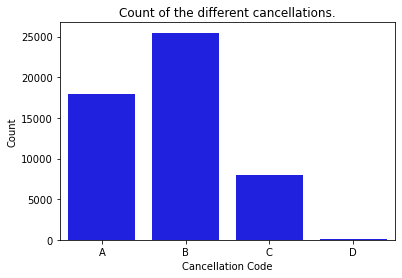

```python
#Create a countplot of the cancellation code variable
sns.countplot(data = flight_copy,  x ='CANCELLATION_CODE', color='blue')
plt.xlabel('Cancellation Code')
plt.ylabel('Count')
plt.title('Count of the different cancellations.');
```

Most flights have been canceled due to extreme weather (actual or forecasted). Very few flights were canceled because of security reasons (D).

How is the distribution of the delay variable? How long were the delays?

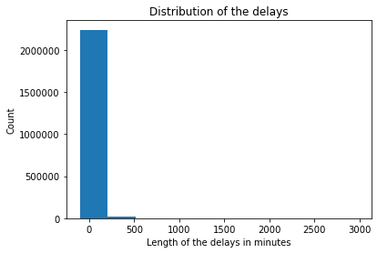

```python
#Plot an histogram of the ARR_DELAY variable
plt.hist(flight_copy['ARR_DELAY'])
plt.ticklabel_format(style='plain', axis='y') #avoid scientific notation
plt.title('Distribution of the delays')
plt.ylabel('Count')
plt.xlabel('Length of the delays in minutes');
```

Outliers are skewing the distribution to the right. Most of our data is clustered around 0. Let's zoom in to see more details.

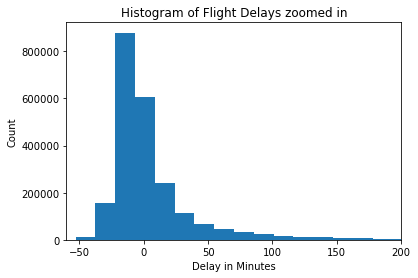

```python
#Zoom in on the x axis
plt.hist(flight_copy['ARR_DELAY'], bins=200)
plt.xlim(-60, 200)
plt.title('Histogram of Flight Delays zoomed in')
plt.ylabel('Count')
plt.xlabel('Delay in Minutes');
```

The histogram shows that the distribution peaks just before 0, meaning that many flights were, in fact, early. It would be interesting to dig deeper into early and late flights. We can do so by creating subsets of the data frame. We will make 3: one for early flights, one for flights on time, and one for delayed flights.

```python
#Create a subset of the dataframe with only the early flights using a query
subset_early = flight_copy.query('ARR_DELAY <= 0.0')
```

```python
#Create a subset of the dataframe with only the flights on time using a query
subset_ontime = flight_copy.query('ARR_DELAY == 0.0')
```

```python
#Create a subset of the dataframe with only the delayed flights using a query
subset_late = flight_copy.query('ARR_DELAY > 0.0')
```

```python
#Create a height variable for a bart chart
x = [len(subset_early) , len(subset_ontime), len(subset_late)]
#Create labels for the bar
labels = ['Early', 'On Time', 'Late']
```

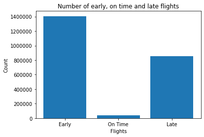

```python
#CCreate the bar plot
plt.bar(labels,x)
plt.ticklabel_format(style='plain', axis='y')
plt.ylabel('Count')
plt.xlabel('Flights')
plt.title('Number of early, on time and late flights');
```

As noted previously, more flights that flew between June and September 2022 were early than late.

Let's dive deeper into those early flights using a histogram.

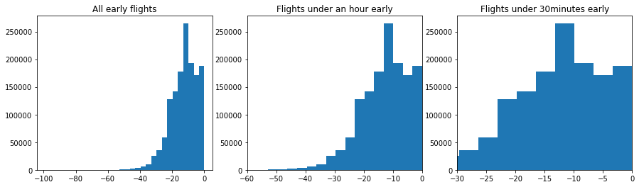

```python
plt.figure(figsize=(15,4))
plt.subplot(1,3,1)
plt.hist(subset_early['ARR_DELAY'],bins=30)
plt.title('All early flights')

plt.subplot(1,3,2)
plt.hist(subset_early['ARR_DELAY'],bins=30)
plt.xlim(-60, 0)
plt.title('Flights under an hour early')


plt.subplot(1,3,3)
plt.hist(subset_early['ARR_DELAY'],bins=30)
plt.xlim(-30, 0)
plt.title('Flights under 30minutes early');
```

Most of the early flights were early by 20 minutes or less. However, there are some outliers - some flights have arrived over 90 minutes early.

Let's focus on the late flights using the subset_late data frame since the delayed flights are our main point of interest.

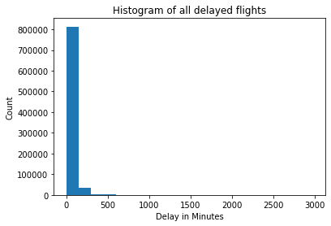

```python
#Histogram of the subset_late dataframe
plt.hist(subset_late['ARR_DELAY'],bins=20)
plt.ylabel('Count')
plt.xlabel('Delay in Minutes')
plt.title('Histogram of all delayed flights');
```

This is where we find the largest outliers, making the distribution skewed to the right. Putting the data on a log scale should give us a clearer view of the data.

```python
#Return statistic for the late fligths under a log scale
np.log10(subset_late['ARR_DELAY'].describe())
```

```
count    5.932258
mean     1.621833
std      1.891301
min      0.000000
25%      0.845098
50%      1.278754
75%      1.672098
max      3.473779
Name: ARR_DELAY, dtype: float64
```

```python
#Create bins for the histogram
bins = 10 ** np.arange(0, 3.48+0.2, 0.2)
```

```python
#Create x ticks and labels
xticks = [1, 5, 15, 30, 60, 120, 240, 1200, 2800]
labels = ['{}'.format(v) for v in xticks]
```

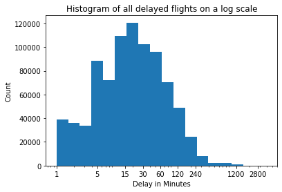

```python
#Histogram of the late fligths on the log scale
plt.hist(subset_late['ARR_DELAY'], bins=bins)
plt.xscale('log')
plt.xticks(xticks, labels)
plt.ylabel('Count')
plt.xlabel('Delay in Minutes')
plt.title('Histogram of all delayed flights on a log scale');
```

Most of the flights were delayed by an hour or less. However, we have huge outliers: some flights have been delayed by a day or more.

We have seen previously the main reasons for cancellation. Let's now dive into the reasons for the delays. As a reminder, there are 5:

Carrier, Weather, NAS, Security, Carrier, and Late Aircraft.

Which delay was most frequent? And which one caused longer delays?

To create a bar plot of the different delays, we need to take a few steps.

```python
#Create a list of the column names for the different delays
delays = ['CARRIER_DELAY', 'WEATHER_DELAY', 'NAS_DELAY','SECURITY_DELAY', 'LATE_AIRCRAFT_DELAY']
```

```python
#Create an empty dictionary
delays_count ={}
```

```python
#Loop through the different delays and add the name of the column and the count to the dictionary
for column in flight_copy[delays]:
    delays_count[column]= flight_copy[column].count()
```

```python
#Get the x values for the bar plot
x_ticks= list(delays_count.keys())
x_ticks
```

```
['CARRIER_DELAY',
 'WEATHER_DELAY',
 'NAS_DELAY',
 'SECURITY_DELAY',
 'LATE_AIRCRAFT_DELAY']
```

```python
#Get the y values for the bar plot
height = list(delays_count.values())
height
```

```
[298940, 30682, 211398, 2558, 251988]
```

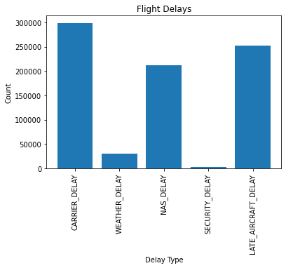

```python
#Plot the bar plot
plt.bar(x_ticks, height)
plt.xticks(rotation=90)
plt.xlabel('Delay Type')
plt.ylabel('Count')
plt.title('Flight Delays');
```

The most frequent delay is carrier delay, followed by late aircraft. Security delays happen rarely. Delays due to weather are also infrequent. However, since weather is the main cause of cancellations, we can deduce that if the weather looks bad, the airline tends to cancel flights instead of merely delaying them.

Most of the delays are due to an issue on the airline side.

Let's look at the different airlines next. How is the data distributed amongst them?

```python
#Sort the carried by descending order
type_order = flight_copy['CARRIER_DESCRIPTION'].value_counts().sort_values(ascending=False).index
```

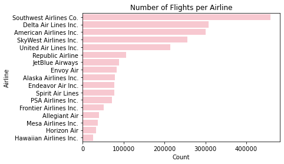

```python
#Create a bar chart
sns.countplot(data=flight_copy, y='CARRIER_DESCRIPTION', color='pink', order=type_order)
plt.ylabel('Airline')
plt.xlabel('Count')
plt.title('Number of Flights per Airline');
```

Unsurprisingly, a large portion of the data is shared between the most commonly used airlines: Southwest, Delta, American, SkyWest, and United.

Let's look into the day of the week, and when most of the flights occured.

```python
#Create the serie to use for our pie plot
days_count = flight_copy['DAY_OF_WEEK'].value_counts()
days_count
```

```
5    354374
4    354167
3    336010
1    333899
7    326717
2    315414
6    292590
Name: DAY_OF_WEEK, dtype: int64
```

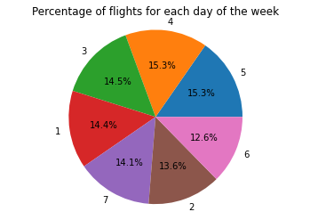

```python
#Create a pie chart
plt.pie(days_count, labels=days_count.index, autopct='%0.1f%%')
plt.axis('equal')
plt.title('Percentage of flights for each day of the week');
```

The data is somewhat evenly distributed between the days of the week. However, we notice that Saturday has the lowest percentage. It does make sense that Saturday is an unpopular day to start your weekend or week away.

What about the months? Is there a month more popular than others?

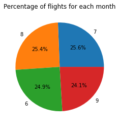

```python
#Create a pie chart for the months
month_counts = flight_copy['MONTH'].value_counts()
plt.pie(month_counts, labels=month_counts.index, autopct='%0.1f%%')
plt.title('Percentage of flights for each month');
```

The flights are pretty evenly distributed throughout the months, with a slightly higher percentage in July and August.

Let's look at the distance variable. How many miles did the planes have to travel?

```python
#print summary statistic using describe
flight_copy['DISTANCE'].describe().apply(lambda x: format(x, 'f'))
```

```
count    2313171.000000
mean         810.674979
std          599.565036
min           31.000000
25%          373.000000
50%          650.000000
75%         1042.000000
max         5095.000000
Name: DISTANCE, dtype: object
```

```python
#Create bins for the histogram
bins = np.arange(31, 5095+250, 250)
```

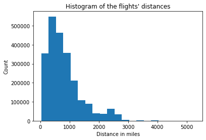

```python
#Create plot
plt.hist(flight_copy['DISTANCE'], bins = bins)
plt.xlabel('Distance in miles')
plt.ylabel('Count')
plt.title("Histogram of the flights' distances");
```

Most of the flights are short-hauls and travel less than 1000 miles. There are outliers, with some flights traveling over 5000 miles.

What is the most popular time of day to fly?

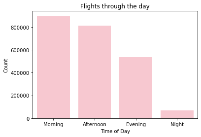

```python
sns.countplot(data = flight_copy, x = 'TIME_OF_DAY', color ='pink')
plt.ylabel('Count')
plt.xlabel('Time of Day')
plt.title('Flights through the day');
```

The most popular time to fly is in the morning, between 6 am and 12 pm, followed by the afternoon (between 12 pm and 6 pm).

The least popular time to fly is at night, i.e., between midnight and 6 am.

### Discuss the distribution(s) of your variable(s) of interest. Were there any unusual points? Did you need to perform any transformations?

We discovered that the ARR_DELAY variable took an extensive range of values, skewing the data heavily to the right. Delays were sometimes as small as 5 minutes and sometimes as long as a day or more.

Since delayed flights are the main point of interest, I isolated them and created a separate subset of the data frame called subset_late. Because of the outliers, I created an histogram of the ARR_DELAY variable, using a log transformation on the x-axis.

### Of the features you investigated, were there any unusual distributions? Did you perform any operations on the data to tidy, adjust, or change the form of the data? If so, why did you do this?

While investigating the arr_delay variable, we noticed significant positive outliers and the mode before zero, meaning that many flights were actually early.

The wide range of data points made it difficult to read, so I separated the data into three subsets: one for the early flights, one for the flights that were on time, and one for the delayed flights. I created a bar chart with a bar for each subset, making it easy to compare each subset. This method showed me that more flights have left early than late. Although this was a notable find, I am still only interested in flights that have been canceled or delayed.

Looking at the different delays, I wanted to compare them to another. To do so, I looped through each delay and saved their names and counts into a dictionary. I used this dictionary to create a bar plot showing the count of each delay next to the other. Another option could have been to use the pd.melt() function on the data frame to reshape the data and create a more general 'Delay' column, but that would have added a lot more rows to an already large data frame, so I decided not to follow this route.

Through this bar chart, we found out that Carrier and Late Aircraft were the most common delays. The Weather didn't cause many delays, probably because the airline chose to cancel rather than delay flights when the Weather was extreme, Weather being the main reason for canceled flights.

## Bivariate Exploration

I am now interested in looking at delays and cancellations correlated with other variables.

Let's start by exploring the relationship between the different airlines and the cancellation variable. As observed previously, many of the flights are spread between the top five main airlines. We then have to work with percentages instead of counts. Were certain airlines more prone to cancellations than others?

```python
#Group the carrier by the number of cancelled flights
#Sort the index in alphabetical order
carrier_cancel = flight_copy.groupby('CARRIER_DESCRIPTION')['CANCELLATION_CODE'].count().sort_index()
carrier_cancel
```

```
CARRIER_DESCRIPTION
Alaska Airlines Inc.        582
Allegiant Air               978
American Airlines Inc.    11766
Delta Air Lines Inc.       5051
Endeavor Air Inc.          3747
Envoy Air                  1031
Frontier Airlines Inc.      971
Hawaiian Airlines Inc.       32
Horizon Air                 115
JetBlue Airways            2502
Mesa Airlines Inc.          889
PSA Airlines Inc.          2143
Republic Airline           5895
SkyWest Airlines Inc.      2039
Southwest Airlines Co.     8279
Spirit Air Lines           1185
United Air Lines Inc.      4317
Name: CANCELLATION_CODE, dtype: int64
```

```python
#Group the carrier by the number of overall flights
#Sort the index in alphabetical order
flights_per_carrier = flight_copy['CARRIER_DESCRIPTION'].value_counts().sort_index()
flights_per_carrier
```

```
Alaska Airlines Inc.       79385
Allegiant Air              40126
American Airlines Inc.    301087
Delta Air Lines Inc.      308424
Endeavor Air Inc.          77716
Envoy Air                  83712
Frontier Airlines Inc.     52337
Hawaiian Airlines Inc.     25592
Horizon Air                33052
JetBlue Airways            89382
Mesa Airlines Inc.         36867
PSA Airlines Inc.          72181
Republic Airline          106598
SkyWest Airlines Inc.     256641
Southwest Airlines Co.    458926
Spirit Air Lines           77486
United Air Lines Inc.     213659
Name: CARRIER_DESCRIPTION, dtype: int64
```

```python
#Get the percentage of canceled flights by dividing the number of canceled flights by the total number of flights.
#Multiply by 100
#Round by two decimals
perc_carrier = np.round((carrier_cancel / flights_per_carrier) * 100,2)\
.reset_index().rename(columns={0: 'PERCENTAGE'}).sort_values(by='PERCENTAGE', ascending=False)
perc_carrier
```

|  | CARRIER_DESCRIPTION | PERCENTAGE |
| --- | --- | --- |
| 12 | Republic Airline | 5.53 |
| 4 | Endeavor Air Inc. | 4.82 |
| 2 | American Airlines Inc. | 3.91 |
| 11 | PSA Airlines Inc. | 2.97 |
| 9 | JetBlue Airways | 2.80 |
| 1 | Allegiant Air | 2.44 |
| 10 | Mesa Airlines Inc. | 2.41 |
| 16 | United Air Lines Inc. | 2.02 |
| 6 | Frontier Airlines Inc. | 1.86 |
| 14 | Southwest Airlines Co. | 1.80 |
| 3 | Delta Air Lines Inc. | 1.64 |
| 15 | Spirit Air Lines | 1.53 |
| 5 | Envoy Air | 1.23 |
| 13 | SkyWest Airlines Inc. | 0.79 |
| 0 | Alaska Airlines Inc. | 0.73 |
| 8 | Horizon Air | 0.35 |
| 7 | Hawaiian Airlines Inc. | 0.13 |

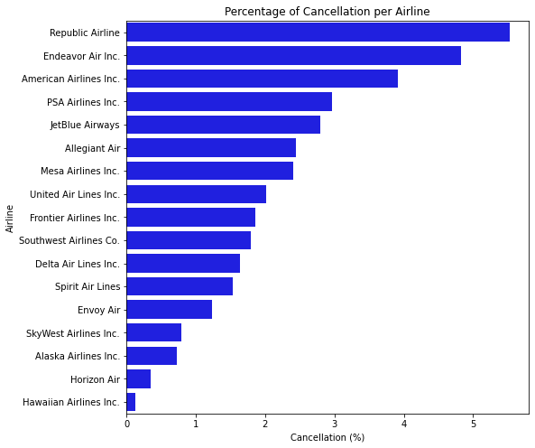

```python
#Create a bar plot of the cancellation percentage per airline
plt.figure(figsize=(8,8))
sns.barplot(data = perc_carrier, x='PERCENTAGE', y='CARRIER_DESCRIPTION', color='blue')
plt.ylabel('Airline')
plt.xlabel('Cancellation (%)')
plt.title('Percentage of Cancellation per Airline');
```

Republic, Endeavor, and American are the three airlines with the highest cancellation percentage.

Let's look into the reasons for cancellations. How are they spread between the different airlines? We will here again use percentage.

```python
#Group by CARRIER_DESCRIPTION and CANCELLATION_CODE to get the number of each code for each airline
#Reset index to create a dataframe, rename the columns
carrier_cancel_code = flight_copy.groupby(['CARRIER_DESCRIPTION','CANCELLATION_CODE']).size().reset_index().rename(columns={0: 'COUNT'})
carrier_cancel_code
```

|  | CARRIER_DESCRIPTION | CANCELLATION_CODE | COUNT |
| --- | --- | --- | --- |
| 0 | Alaska Airlines Inc. | A | 397 |
| 1 | Alaska Airlines Inc. | B | 174 |
| 2 | Alaska Airlines Inc. | C | 10 |
| 3 | Alaska Airlines Inc. | D | 1 |
| 4 | Allegiant Air | A | 400 |
| 5 | Allegiant Air | B | 460 |
| 6 | Allegiant Air | C | 106 |
| 7 | Allegiant Air | D | 12 |
| 8 | American Airlines Inc. | A | 4953 |
| 9 | American Airlines Inc. | B | 6421 |
| 10 | American Airlines Inc. | C | 390 |
| 11 | American Airlines Inc. | D | 2 |
| 12 | Delta Air Lines Inc. | A | 3779 |
| 13 | Delta Air Lines Inc. | B | 858 |
| 14 | Delta Air Lines Inc. | C | 414 |
| 15 | Delta Air Lines Inc. | D | 0 |
| 16 | Endeavor Air Inc. | A | 1323 |
| 17 | Endeavor Air Inc. | B | 152 |
| 18 | Endeavor Air Inc. | C | 2272 |
| 19 | Endeavor Air Inc. | D | 0 |
| 20 | Envoy Air | A | 120 |
| 21 | Envoy Air | B | 511 |
| 22 | Envoy Air | C | 400 |
| 23 | Envoy Air | D | 0 |
| 24 | Frontier Airlines Inc. | A | 402 |
| 25 | Frontier Airlines Inc. | B | 569 |
| 26 | Frontier Airlines Inc. | C | 0 |
| 27 | Frontier Airlines Inc. | D | 0 |
| 28 | Hawaiian Airlines Inc. | A | 32 |
| 29 | Hawaiian Airlines Inc. | B | 0 |
| 30 | Hawaiian Airlines Inc. | C | 0 |
| 31 | Hawaiian Airlines Inc. | D | 0 |
| 32 | Horizon Air | A | 86 |
| 33 | Horizon Air | B | 18 |
| 34 | Horizon Air | C | 11 |
| 35 | Horizon Air | D | 0 |
| 36 | JetBlue Airways | A | 827 |
| 37 | JetBlue Airways | B | 1028 |
| 38 | JetBlue Airways | C | 647 |
| 39 | JetBlue Airways | D | 0 |
| 40 | Mesa Airlines Inc. | A | 462 |
| 41 | Mesa Airlines Inc. | B | 295 |
| 42 | Mesa Airlines Inc. | C | 132 |
| 43 | Mesa Airlines Inc. | D | 0 |
| 44 | PSA Airlines Inc. | A | 418 |
| 45 | PSA Airlines Inc. | B | 1642 |
| 46 | PSA Airlines Inc. | C | 83 |
| 47 | PSA Airlines Inc. | D | 0 |
| 48 | Republic Airline | A | 131 |
| 49 | Republic Airline | B | 3994 |
| 50 | Republic Airline | C | 1770 |
| 51 | Republic Airline | D | 0 |
| 52 | SkyWest Airlines Inc. | A | 193 |
| 53 | SkyWest Airlines Inc. | B | 1616 |
| 54 | SkyWest Airlines Inc. | C | 222 |
| 55 | SkyWest Airlines Inc. | D | 8 |
| 56 | Southwest Airlines Co. | A | 2282 |
| 57 | Southwest Airlines Co. | B | 4812 |
| 58 | Southwest Airlines Co. | C | 1074 |
| 59 | Southwest Airlines Co. | D | 111 |
| 60 | Spirit Air Lines | A | 95 |
| 61 | Spirit Air Lines | B | 992 |
| 62 | Spirit Air Lines | C | 98 |
| 63 | Spirit Air Lines | D | 0 |
| 64 | United Air Lines Inc. | A | 1991 |
| 65 | United Air Lines Inc. | B | 1932 |
| 66 | United Air Lines Inc. | C | 394 |
| 67 | United Air Lines Inc. | D | 0 |

```python
#Turn flights_per carrier (as defined above) into a dataframe
flights_per_carrier_df = flights_per_carrier.reset_index().rename(columns={'index': 'CARRIER_DESCRIPTION', 'CARRIER_DESCRIPTION': 'FLIGHT_COUNT'})
flights_per_carrier_df
```

|  | CARRIER_DESCRIPTION | FLIGHT_COUNT |
| --- | --- | --- |
| 0 | Alaska Airlines Inc. | 79385 |
| 1 | Allegiant Air | 40126 |
| 2 | American Airlines Inc. | 301087 |
| 3 | Delta Air Lines Inc. | 308424 |
| 4 | Endeavor Air Inc. | 77716 |
| 5 | Envoy Air | 83712 |
| 6 | Frontier Airlines Inc. | 52337 |
| 7 | Hawaiian Airlines Inc. | 25592 |
| 8 | Horizon Air | 33052 |
| 9 | JetBlue Airways | 89382 |
| 10 | Mesa Airlines Inc. | 36867 |
| 11 | PSA Airlines Inc. | 72181 |
| 12 | Republic Airline | 106598 |
| 13 | SkyWest Airlines Inc. | 256641 |
| 14 | Southwest Airlines Co. | 458926 |
| 15 | Spirit Air Lines | 77486 |
| 16 | United Air Lines Inc. | 213659 |

```python
#Create a new dataframe by merging carrier_cancel_code and flights_per_carrier_df together
carrier_flight_code = carrier_cancel_code.merge(flights_per_carrier_df)
carrier_flight_code
```

|  | CARRIER_DESCRIPTION | CANCELLATION_CODE | COUNT | FLIGHT_COUNT |
| --- | --- | --- | --- | --- |
| 0 | Alaska Airlines Inc. | A | 397 | 79385 |
| 1 | Alaska Airlines Inc. | B | 174 | 79385 |
| 2 | Alaska Airlines Inc. | C | 10 | 79385 |
| 3 | Alaska Airlines Inc. | D | 1 | 79385 |
| 4 | Allegiant Air | A | 400 | 40126 |
| 5 | Allegiant Air | B | 460 | 40126 |
| 6 | Allegiant Air | C | 106 | 40126 |
| 7 | Allegiant Air | D | 12 | 40126 |
| 8 | American Airlines Inc. | A | 4953 | 301087 |
| 9 | American Airlines Inc. | B | 6421 | 301087 |
| 10 | American Airlines Inc. | C | 390 | 301087 |
| 11 | American Airlines Inc. | D | 2 | 301087 |
| 12 | Delta Air Lines Inc. | A | 3779 | 308424 |
| 13 | Delta Air Lines Inc. | B | 858 | 308424 |
| 14 | Delta Air Lines Inc. | C | 414 | 308424 |
| 15 | Delta Air Lines Inc. | D | 0 | 308424 |
| 16 | Endeavor Air Inc. | A | 1323 | 77716 |
| 17 | Endeavor Air Inc. | B | 152 | 77716 |
| 18 | Endeavor Air Inc. | C | 2272 | 77716 |
| 19 | Endeavor Air Inc. | D | 0 | 77716 |
| 20 | Envoy Air | A | 120 | 83712 |
| 21 | Envoy Air | B | 511 | 83712 |
| 22 | Envoy Air | C | 400 | 83712 |
| 23 | Envoy Air | D | 0 | 83712 |
| 24 | Frontier Airlines Inc. | A | 402 | 52337 |
| 25 | Frontier Airlines Inc. | B | 569 | 52337 |
| 26 | Frontier Airlines Inc. | C | 0 | 52337 |
| 27 | Frontier Airlines Inc. | D | 0 | 52337 |
| 28 | Hawaiian Airlines Inc. | A | 32 | 25592 |
| 29 | Hawaiian Airlines Inc. | B | 0 | 25592 |
| 30 | Hawaiian Airlines Inc. | C | 0 | 25592 |
| 31 | Hawaiian Airlines Inc. | D | 0 | 25592 |
| 32 | Horizon Air | A | 86 | 33052 |
| 33 | Horizon Air | B | 18 | 33052 |
| 34 | Horizon Air | C | 11 | 33052 |
| 35 | Horizon Air | D | 0 | 33052 |
| 36 | JetBlue Airways | A | 827 | 89382 |
| 37 | JetBlue Airways | B | 1028 | 89382 |
| 38 | JetBlue Airways | C | 647 | 89382 |
| 39 | JetBlue Airways | D | 0 | 89382 |
| 40 | Mesa Airlines Inc. | A | 462 | 36867 |
| 41 | Mesa Airlines Inc. | B | 295 | 36867 |
| 42 | Mesa Airlines Inc. | C | 132 | 36867 |
| 43 | Mesa Airlines Inc. | D | 0 | 36867 |
| 44 | PSA Airlines Inc. | A | 418 | 72181 |
| 45 | PSA Airlines Inc. | B | 1642 | 72181 |
| 46 | PSA Airlines Inc. | C | 83 | 72181 |
| 47 | PSA Airlines Inc. | D | 0 | 72181 |
| 48 | Republic Airline | A | 131 | 106598 |
| 49 | Republic Airline | B | 3994 | 106598 |
| 50 | Republic Airline | C | 1770 | 106598 |
| 51 | Republic Airline | D | 0 | 106598 |
| 52 | SkyWest Airlines Inc. | A | 193 | 256641 |
| 53 | SkyWest Airlines Inc. | B | 1616 | 256641 |
| 54 | SkyWest Airlines Inc. | C | 222 | 256641 |
| 55 | SkyWest Airlines Inc. | D | 8 | 256641 |
| 56 | Southwest Airlines Co. | A | 2282 | 458926 |
| 57 | Southwest Airlines Co. | B | 4812 | 458926 |
| 58 | Southwest Airlines Co. | C | 1074 | 458926 |
| 59 | Southwest Airlines Co. | D | 111 | 458926 |
| 60 | Spirit Air Lines | A | 95 | 77486 |
| 61 | Spirit Air Lines | B | 992 | 77486 |
| 62 | Spirit Air Lines | C | 98 | 77486 |
| 63 | Spirit Air Lines | D | 0 | 77486 |
| 64 | United Air Lines Inc. | A | 1991 | 213659 |
| 65 | United Air Lines Inc. | B | 1932 | 213659 |
| 66 | United Air Lines Inc. | C | 394 | 213659 |
| 67 | United Air Lines Inc. | D | 0 | 213659 |

```python
#Create a new column called 'perc' that is the product of the column COUNT divided by FLIGHT_COUNT, time 100,
#rounded to 2 decimal
carrier_flight_code['PERC'] = np.round((carrier_flight_code['COUNT'] / carrier_flight_code['FLIGHT_COUNT']) * 100, 2)
```

```python
#Print the first 5 rows of carrier_flight_code
carrier_flight_code.head()
```

|  | CARRIER_DESCRIPTION | CANCELLATION_CODE | COUNT | FLIGHT_COUNT | PERC |
| --- | --- | --- | --- | --- | --- |
| 0 | Alaska Airlines Inc. | A | 397 | 79385 | 0.50 |
| 1 | Alaska Airlines Inc. | B | 174 | 79385 | 0.22 |
| 2 | Alaska Airlines Inc. | C | 10 | 79385 | 0.01 |
| 3 | Alaska Airlines Inc. | D | 1 | 79385 | 0.00 |
| 4 | Allegiant Air | A | 400 | 40126 | 1.00 |

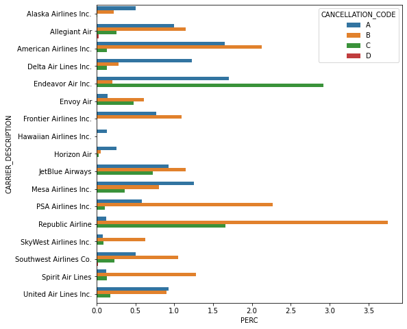

```python
#Create a bar plot of the cancellation code percentage per airline
plt.figure(figsize=(8,8))
sns.barplot(data=carrier_flight_code, y='CARRIER_DESCRIPTION', x='PERC', hue='CANCELLATION_CODE');
```

As a reminder:

```
A: Carrier
B: Weather
C: National Air System
D: Security
```

Weather is the main reason for cancellation, followed by Carrier. However, Endeavor Air sticks out as having had many more issues with NAS than most airlines. NAS percentage is also high with Republic Airline.

I want to investigate the number of flight cancellations per day of the week. However, as seen in the univariate visualization, some days had more scheduled flights than others, which would have resulted in more cancellations. Therefore, we need to look at the percentage of canceled flights rather than the number.

Did cancellations happen more frequently on a specific day of the week?

```python
#Group by the day of the week and count the number of cancellation per day
day_cancelled = flight_copy.groupby('DAY_OF_WEEK')['CANCELLATION_CODE'].count()
day_cancelled
```

```
DAY_OF_WEEK
1     7252
2     5004
3     8300
4    10787
5     8480
6     4916
7     6783
Name: CANCELLATION_CODE, dtype: int64
```

```python
#Get the number of flight per day
number_flights = flight_copy['DAY_OF_WEEK'].value_counts().sort_index()
number_flights
```

```
1    333899
2    315414
3    336010
4    354167
5    354374
6    292590
7    326717
Name: DAY_OF_WEEK, dtype: int64
```

```python
#Get the percentage of cancelled flight per day
perc_day = np.round((day_cancelled / number_flights) * 100, 2).reset_index().rename(columns={0: 'PERC'})
perc_day
```

|  | DAY_OF_WEEK | PERC |
| --- | --- | --- |
| 0 | 1 | 2.17 |
| 1 | 2 | 1.59 |
| 2 | 3 | 2.47 |
| 3 | 4 | 3.05 |
| 4 | 5 | 2.39 |
| 5 | 6 | 1.68 |
| 6 | 7 | 2.08 |

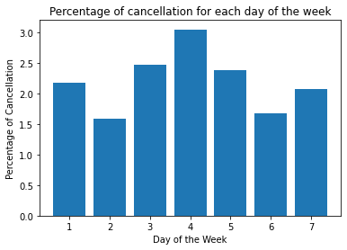

```python
#Create a bar chart
plt.bar(perc_day['DAY_OF_WEEK'], perc_day['PERC'])
plt.ylabel('Percentage of Cancellation')
plt.xlabel('Day of the Week')
plt.title('Percentage of cancellation for each day of the week');
```

Flights were more likely to be canceled on Thursdays, with fewer cancellations on Tuesdays and Saturdays.

Now, let's do the same thing for each month: What was the percentage of canceled flights per month?

```python
#Group by month and cancellation code
month_plot = flight_copy.groupby('MONTH')['CANCELLATION_CODE'].count()
month_plot
```

```
MONTH
6    17876
7    10546
8    14401
9     8699
Name: CANCELLATION_CODE, dtype: int64
```

```python
#Get the number of flights per month
flights_per_month = flight_copy['MONTH'].value_counts().sort_index()
flights_per_month
```

```
6    575629
7    593095
8    588020
9    556427
Name: MONTH, dtype: int64
```

```python
#Get the percentage of cancelled flights per month
perc_month = np.round((month_plot / flights_per_month) * 100, 2).reset_index().rename(columns={0: 'PERC'})
perc_month
```

|  | MONTH | PERC |
| --- | --- | --- |
| 0 | 6 | 3.11 |
| 1 | 7 | 1.78 |
| 2 | 8 | 2.45 |
| 3 | 9 | 1.56 |

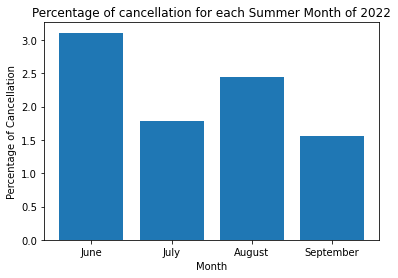

```python
#Create a bar plot
plt.bar(perc_month['MONTH'], perc_month['PERC'])
plt.xlabel('Month')
plt.ylabel('Percentage of Cancellation')
plt.xticks([6,7,8,9], labels=['June', 'July', 'August', 'September'])
plt.title('Percentage of cancellation for each Summer Month of 2022');
```

June had the most cancellations, followed by August, July, and September.

Let's examine the state of origin from which the flights were departing. Have any state had more cancellations than others?

Some airports are more frequented than others - like New York, Chicago, or Atlanta, and it would make sense for the states where those airports are to have the most cancellations. Here again, we need to work with percentage.

```python
#Group the origin states by the number of cancellation
state_cancel_or = flight_copy.groupby('ORIGIN_STATE_ABR')['CANCELLATION_CODE'].count().sort_index()
state_cancel_or
```

```
ORIGIN_STATE_ABR
AK     225
AL     214
AR     110
AZ     872
CA    3274
CO    1492
CT     190
DE       0
FL    5965
GA    1846
HI     136
IA     122
ID      87
IL    2864
IN     412
KS      57
KY     595
LA     353
MA    1320
MD     921
ME     339
MI     892
MN     424
MO     839
MS      54
MT      81
NC    3123
ND      33
NE     156
NH      74
NJ    2666
NM      77
NV    1156
NY    6131
OH     794
OK     172
OR     220
PA    1394
PR     305
RI     199
SC     774
SD      59
TN     958
TT       0
TX    4973
UT     360
VA    3100
VI      55
VT     124
WA     503
WI     349
WV      41
WY      42
Name: CANCELLATION_CODE, dtype: int64
```

```python
#Get the number of fligths per state
flights_per_state_or = flight_copy['ORIGIN_STATE_ABR'].value_counts().sort_index()
flights_per_state_or
```

```
AK     17056
AL      9587
AR      8245
AZ     61496
CA    258713
CO    106521
CT      7850
DE         1
FL    180117
GA    117156
HI     42566
IA      8602
ID     12723
IL    126130
IN     17931
KS      4995
KY     22820
LA     21691
MA     50632
MD     30528
ME      6871
MI     54954
MN     44026
MO     39882
MS      4559
MT     11387
NC     95918
ND      5382
NE      8333
NH      2571
NJ     43539
NM      8097
NV     68779
NY    130921
OH     29578
OK     13253
OR     30151
PA     49051
PR     10740
RI      5195
SC     23299
SD      4818
TN     45027
TT       432
TX    243258
UT     40439
VA     83356
VI      2067
VT      3217
WA     76918
WI     16257
WV      1769
WY      3767
Name: ORIGIN_STATE_ABR, dtype: int64
```

```python
#Get the percentage of flights per state.
perc_state_or = np.round((state_cancel_or / flights_per_state_or) * 100, 2).reset_index().rename(columns={0: 'PERCENTAGE'})
#Sort the percentage column by descending order.
perc_state_or = perc_state_or.sort_values(by='PERCENTAGE', ascending=False)
```

```python
#Print perc_state_or
perc_state_or
```

|  | ORIGIN_STATE_ABR | PERCENTAGE |
| --- | --- | --- |
| 30 | NJ | 6.12 |
| 20 | ME | 4.93 |
| 33 | NY | 4.68 |
| 48 | VT | 3.85 |
| 39 | RI | 3.83 |
| 46 | VA | 3.72 |
| 40 | SC | 3.32 |
| 8 | FL | 3.31 |
| 26 | NC | 3.26 |
| 19 | MD | 3.02 |
| 29 | NH | 2.88 |
| 38 | PR | 2.84 |
| 37 | PA | 2.84 |
| 34 | OH | 2.68 |
| 47 | VI | 2.66 |
| 16 | KY | 2.61 |
| 18 | MA | 2.61 |
| 6 | CT | 2.42 |
| 51 | WV | 2.32 |
| 14 | IN | 2.30 |
| 13 | IL | 2.27 |
| 1 | AL | 2.23 |
| 50 | WI | 2.15 |
| 42 | TN | 2.13 |
| 23 | MO | 2.10 |
| 44 | TX | 2.04 |
| 28 | NE | 1.87 |
| 32 | NV | 1.68 |
| 17 | LA | 1.63 |
| 21 | MI | 1.62 |
| 9 | GA | 1.58 |
| 11 | IA | 1.42 |
| 3 | AZ | 1.42 |
| 5 | CO | 1.40 |
| 2 | AR | 1.33 |
| 0 | AK | 1.32 |
| 35 | OK | 1.30 |
| 4 | CA | 1.27 |
| 41 | SD | 1.22 |
| 24 | MS | 1.18 |
| 15 | KS | 1.14 |
| 52 | WY | 1.11 |
| 22 | MN | 0.96 |
| 31 | NM | 0.95 |
| 45 | UT | 0.89 |
| 36 | OR | 0.73 |
| 25 | MT | 0.71 |
| 12 | ID | 0.68 |
| 49 | WA | 0.65 |
| 27 | ND | 0.61 |
| 10 | HI | 0.32 |
| 43 | TT | 0.00 |
| 7 | DE | 0.00 |

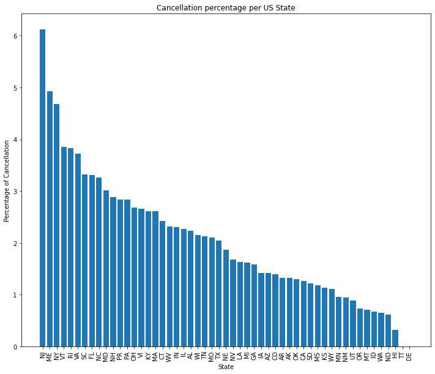

```python
#Create bar chart
plt.figure(figsize=(12,10))
plt.bar(perc_state_or['ORIGIN_STATE_ABR'], perc_state_or['PERCENTAGE'])
plt.xlabel('State')
plt.ylabel('Percentage of Cancellation')
plt.xticks(rotation=90)
plt.title('Cancellation percentage per US State');
```

The number of states makes this chart difficult to read. Let's chart the top ten states instead.

```python
#Get the first 10 states by using head()
top_ten_or = perc_state_or.head(10)
top_ten_or
```

|  | ORIGIN_STATE_ABR | PERCENTAGE |
| --- | --- | --- |
| 30 | NJ | 6.12 |
| 20 | ME | 4.93 |
| 33 | NY | 4.68 |
| 48 | VT | 3.85 |
| 39 | RI | 3.83 |
| 46 | VA | 3.72 |
| 40 | SC | 3.32 |
| 8 | FL | 3.31 |
| 26 | NC | 3.26 |
| 19 | MD | 3.02 |

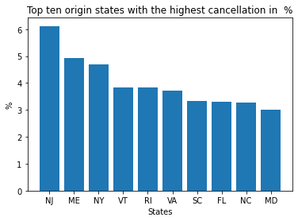

```python
#Plot the bar chart again using top_ten_or
plt.bar(top_ten_or['ORIGIN_STATE_ABR'], top_ten_or['PERCENTAGE'])
plt.xlabel('States')
plt.ylabel("%")
plt.title('Top ten origin states with the highest cancellation in  %');
```

Interestingly, it appears that the East Coast is faring the worst, with New Jersey, Maine, New York, and Rhode Island all in the top five, New Jersey being number 1 with a 6% cancellation rate.

What about the states the flights are flying to instead of from? Let's create the same bar chart but with the destination state instead of the origin.

```python
#Group the destination states by the number of cancellation
state_cancel_dest = flight_copy.groupby('DEST_STATE_ABR')['CANCELLATION_CODE'].count().sort_index()
state_cancel_dest
```

```
DEST_STATE_ABR
AK     211
AL     176
AR     103
AZ     944
CA    3224
CO    1568
CT     191
DE       0
FL    5977
GA    1864
HI     108
IA     125
ID      76
IL    2971
IN     457
KS      60
KY     599
LA     330
MA    1318
MD     956
ME     319
MI     871
MN     409
MO     776
MS      51
MT      57
NC    3197
ND      25
NE     138
NH      94
NJ    2665
NM      64
NV    1145
NY    6127
OH     795
OK     167
OR     209
PA    1422
PR     296
RI     163
SC     767
SD      45
TN     877
TT       0
TX    5000
UT     359
VA    3079
VI      48
VT     129
WA     566
WI     320
WV      45
WY      39
Name: CANCELLATION_CODE, dtype: int64
```

```python
#Get the number of fligths per destination state
flights_per_state_dest = flight_copy['DEST_STATE_ABR'].value_counts().sort_index()
flights_per_state_dest
```

```
AK     17045
AL      9603
AR      8266
AZ     61441
CA    259198
CO    106229
CT      7881
DE         1
FL    179782
GA    117137
HI     42554
IA      8621
ID     12741
IL    126085
IN     17964
KS      4999
KY     22864
LA     21713
MA     50682
MD     30537
ME      6874
MI     54998
MN     44104
MO     39958
MS      4557
MT     11401
NC     95847
ND      5394
NE      8339
NH      2584
NJ     43368
NM      8110
NV     68758
NY    130776
OH     29620
OK     13288
OR     30207
PA     49110
PR     10737
RI      5220
SC     23308
SD      4824
TN     45074
TT       432
TX    242956
UT     40502
VA     83347
VI      2115
VT      3221
WA     76997
WI     16243
WV      1766
WY      3793
Name: DEST_STATE_ABR, dtype: int64
```

```python
#Get the percentage of flights per state.
perc_state_dest = np.round((state_cancel_dest / flights_per_state_dest) * 100, 2).reset_index().rename(columns={0: 'PERCENTAGE'})
#Sort the percentage column by descending order, get the first 10 rows.
perc_state_dest = perc_state_dest.sort_values(by='PERCENTAGE', ascending=False).head(10)
```

```python
#Print perc_state_dest
perc_state_dest
```

|  | DEST_STATE_ABR | PERCENTAGE |
| --- | --- | --- |
| 30 | NJ | 6.15 |
| 33 | NY | 4.69 |
| 20 | ME | 4.64 |
| 48 | VT | 4.00 |
| 46 | VA | 3.69 |
| 29 | NH | 3.64 |
| 26 | NC | 3.34 |
| 8 | FL | 3.32 |
| 40 | SC | 3.29 |
| 19 | MD | 3.13 |

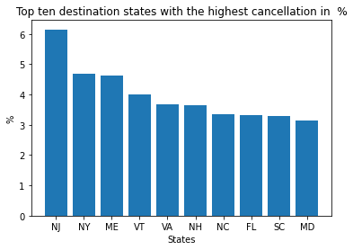

```python
#Plot the bar chart for perc_state_dest
plt.bar(perc_state_dest['DEST_STATE_ABR'], perc_state_dest['PERCENTAGE'])
plt.xlabel('States')
plt.ylabel("%")
plt.title('Top ten destination states with the highest cancellation in  %');
```

We also find New Jersey, New York, Maine, and Vermont in the top 10, with a 4 to 6% cancellation rate.

Let's look into the average delays for each origin and destination state. Which states had the most delays on average? We will focus on the top 10.

```python
#Create a new column with the sum of each individual delays.
flight_copy['TOTAL_DELAY'] = flight_copy[['CARRIER_DELAY', 'WEATHER_DELAY', 'NAS_DELAY', 'SECURITY_DELAY',\
                                          'LATE_AIRCRAFT_DELAY']].sum(axis=1)
```

```python
#Create a new dataframe by grouping ORIGIN_CITY_NAME together and getting the TOTAL_DELAY average
delay_origin_state = flight_copy.groupby('ORIGIN_STATE_ABR')['TOTAL_DELAY'].mean().sort_values(ascending=False)\
.reset_index().rename(columns={'TOTAL_DELAY': 'MEAN_DELAY'}).head(10)
delay_origin_state
```

|  | ORIGIN_STATE_ABR | MEAN_DELAY |
| --- | --- | --- |
| 0 | DE | 168.000000 |
| 1 | WV | 21.935557 |
| 2 | PR | 20.138361 |
| 3 | NJ | 18.617860 |
| 4 | FL | 18.504222 |
| 5 | NY | 18.400914 |
| 6 | NV | 17.757746 |
| 7 | MD | 16.946639 |
| 8 | VT | 16.502021 |
| 9 | MA | 16.373380 |

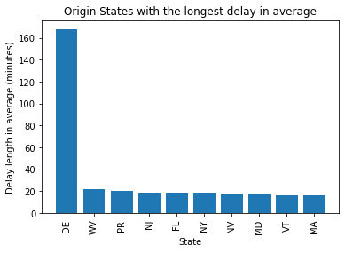

```python
#Print the dataframe for the top 10
plt.bar(delay_origin_state['ORIGIN_STATE_ABR'], delay_origin_state['MEAN_DELAY'])
plt.xlabel('State')
plt.ylabel('Delay length in average (minutes)')
plt.xticks(rotation=90)
plt.title('Origin States with the longest delay in average');
```

Let's do the same thing for the state the flights are flying to, instead of from.

```python
#Create a new dataframe by grouping DEST_CITY_NAME together and getting the TOTAL_DELAY average
delay_dest_state = flight_copy.groupby('DEST_STATE_ABR')['TOTAL_DELAY'].mean().sort_values(ascending=False)\
.reset_index().rename(columns={'TOTAL_DELAY': 'MEAN_DELAY'}).head(10)
delay_dest_state
```

|  | DEST_STATE_ABR | MEAN_DELAY |
| --- | --- | --- |
| 0 | DE | 205.000000 |
| 1 | PR | 20.806836 |
| 2 | NJ | 18.661617 |
| 3 | NY | 18.337960 |
| 4 | FL | 17.866210 |
| 5 | MA | 17.777337 |
| 6 | CT | 16.729857 |
| 7 | IN | 16.519650 |
| 8 | NV | 16.006370 |
| 9 | KY | 15.912526 |

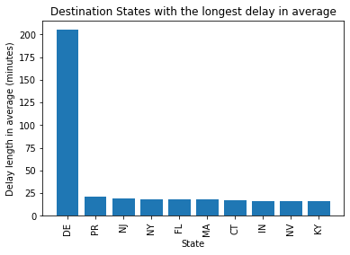

```python
#Print the dataframe for the top 10
plt.bar(delay_dest_state['DEST_STATE_ABR'], delay_dest_state['MEAN_DELAY'])
plt.xlabel('State')
plt.ylabel('Delay length in average (minutes)')
plt.xticks(rotation=90)
plt.title('Destination States with the longest delay in average');
```

```python
#Create a sample of the dataset for readibility
sample_df = flight_copy.sample(frac=0.2)
```

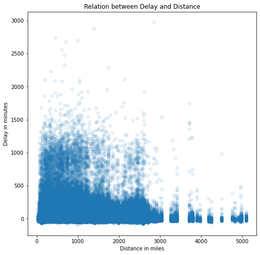

```python
#Create a scatter plot of the distance and delay variable
plt.figure(figsize=(8,8))
plt.scatter(flight_copy['DISTANCE'], flight_copy['ARR_DELAY'], alpha=0.1)
plt.xlabel('Distance in miles')
plt.ylabel('Delay in minutes')
plt.title('Relation between Delay and Distance');
```

There is a slight correlation between delay and distance but a counter-intuitive one. Flights under 4000 miles suffered longer delays than flights over 4000 miles. However, the scatter plot makes it difficult to read any negative values.

I am also interested in the AIR_TIME variable. Distance is linked to air time (farther away means more time spent flying), but I would like to explore this variable in correlation with the ARR_DELAY.

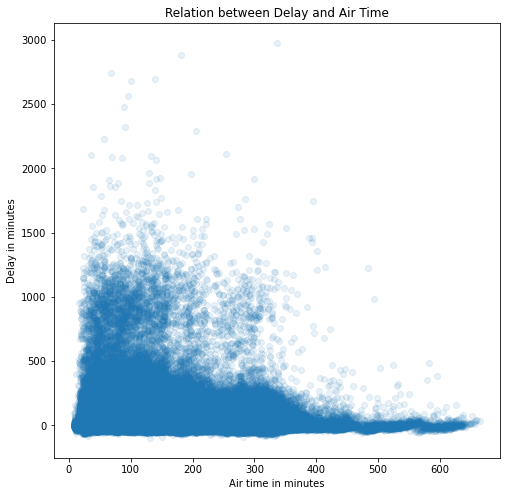

```python
plt.figure(figsize=(8,8))
plt.scatter(flight_copy['AIR_TIME'], flight_copy['ARR_DELAY'], alpha=0.1)
plt.xlabel('Air time in minutes')
plt.ylabel('Delay in minutes')
plt.title('Relation between Delay and Air Time');
```

This scatterplot is very similar to the previous one. Here, too, we can see that longer flights (flights with longer air time) suffered shorter delays than shorter flights. Again, reading negative values (i.e., flights departing early) is difficult.

To make the delay variable easier to read - especially the negative values, which are the flights that have departed early - I have decided to separate the ARR_DELAY variable into bins: flights that are Over an Hour Early, 30 to 60 minutes early, Less than 30 minutes early, On Time, Less than an hour late, 1 to 2 hours late, 2 to 4 hours late, 4 to 8 hours late, 8 to 12 hours late, 12 to 24 hours late, and Over 24 hours late.

Once separated into bins, I will compare those to the distance variable.

```python
#Create the bin edges and the bin labels
bin_edges = [-99.0, -60.0, -30.0, -0.1, 0.1, 60.0, 120.0, 240.0, 480.0, 720.0, 1440.0, 2977.0 ]
labels = ['Over an hour early', '30 to 60 minutes early', 'Less than 30 minutes early', 'On time',
          'Less than an hour late', '1 to 2 hours late', '2 to 4 hours late', '4 to 8 hours late', '8 to 12 hours late',
          '12 to 24 hours late', 'Over 24hours late']
```

```python
#Create a new column called 'bin' to store the new variable
flight_copy['ARR_DELAY_BINS'] = pd.cut(x=flight_copy['ARR_DELAY'], bins=bin_edges, labels=labels, right=False)
```

```python
#Print a sample of the arr_delay and the bins columns
flight_copy[['ARR_DELAY', 'ARR_DELAY_BINS']].sample(100)
```

|  | ARR_DELAY | ARR_DELAY_BINS |
| --- | --- | --- |
| 2044620 | 7.0 | Less than an hour late |
| 2272291 | -21.0 | Less than 30 minutes early |
| 1785176 | -4.0 | Less than 30 minutes early |
| 1954123 | -28.0 | Less than 30 minutes early |
| 2313330 | -7.0 | Less than 30 minutes early |
| 1703876 | 105.0 | 1 to 2 hours late |
| 1916521 | 18.0 | Less than an hour late |
| 1029169 | -18.0 | Less than 30 minutes early |
| 194687 | 2.0 | Less than an hour late |
| 66296 | 25.0 | Less than an hour late |
| 573861 | -1.0 | Less than 30 minutes early |
| 125469 | -17.0 | Less than 30 minutes early |
| 1824701 | 30.0 | Less than an hour late |
| 415462 | 5.0 | Less than an hour late |
| 1761739 | 20.0 | Less than an hour late |
| 2007256 | -33.0 | 30 to 60 minutes early |
| 917415 | 19.0 | Less than an hour late |
| 467548 | -11.0 | Less than 30 minutes early |
| 704630 | 0.0 | On time |
| 949100 | 22.0 | Less than an hour late |
| 68284 | -5.0 | Less than 30 minutes early |
| 124248 | -10.0 | Less than 30 minutes early |
| 491135 | 74.0 | 1 to 2 hours late |
| 2153409 | -7.0 | Less than 30 minutes early |
| 1302941 | -20.0 | Less than 30 minutes early |
| 1894410 | -9.0 | Less than 30 minutes early |
| 556474 | -5.0 | Less than 30 minutes early |
| 845151 | -14.0 | Less than 30 minutes early |
| 539255 | 1.0 | Less than an hour late |
| 1861240 | -11.0 | Less than 30 minutes early |

[output cut: 70 more lines]

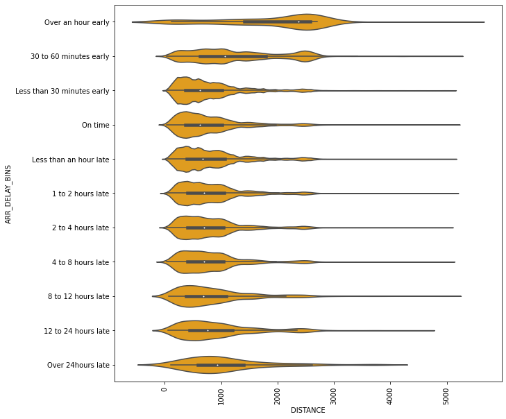

```python
#Create the violinplot
plt.figure(figsize=(10,10))
sns.violinplot(data=flight_copy, x='DISTANCE', y='ARR_DELAY_BINS', color='orange')
plt.xticks(rotation=90);
```

The early flights are easier to read in this violin plot. The flights that were between 2000 and 3000 miles long were the flights that were most likely to be early by over an hour. There is also a small peak on the '30 to 60 minutes early' bin for those same flights. We can also see that long-haul flights, specifically those over 4500 miles, were never more than 24 hours late.

The delays are separated in 5 categories: Carrier, Weather, NAS, Security, Late Aircraft. We saw previously that Carrier and Late Aircraft were the two delays that happened the most frequently. However, which delays caused the longest delays?

We can find this out by getting the mean of each delay.

```python
#Create a subset of the dataset with the mean of all the different delays
delays_mean = flight_copy[['CARRIER_DELAY', 'WEATHER_DELAY', 'NAS_DELAY','SECURITY_DELAY',
                          'LATE_AIRCRAFT_DELAY']].mean().reset_index().rename(columns={'index':'Delays', 0:'Mean'})
#Print this dataframe
delays_mean
```

|  | Delays | Mean |
| --- | --- | --- |
| 0 | CARRIER_DELAY | 43.860022 |
| 1 | WEATHER_DELAY | 62.066065 |
| 2 | NAS_DELAY | 26.559632 |
| 3 | SECURITY_DELAY | 31.187647 |
| 4 | LATE_AIRCRAFT_DELAY | 50.663246 |

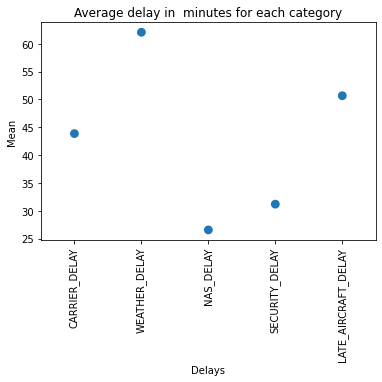

```python
#Create a point plot with the mean of each delay
sns.pointplot(data=delays_mean, x='Delays', y='Mean', linestyles="")
plt.xlabel('Delays')
plt.ylabel('Mean')
plt.ticklabel_format(style='plain', axis='y')
plt.xticks(rotation=90)
plt.title('Average delay in  minutes for each category');
```

Even though weather delays didn't happen frequently, they tended to create longer delays, with a mean of over 60. This means that a delay caused by the weather was, on average, an hour long. Carrier delays were the most frequent delay. However, it didn't cause the most prolonged delays, with an average of just under 45 minutes. NAS delays were relatively short.

Which airlines suffered the longest delays on average?

Before plotting the total delay average, we need to replace all the 0 values with a null value. The seaborn bar chart will automatically plot the average for us, so we do not need to take any extra steps.

```python
#Replace the 0 values by NaN
flight_copy['TOTAL_DELAY'] = flight_copy['TOTAL_DELAY'].replace(0.0, np.nan)
```

```python
#Create the order for the y ticks
order = flight_copy.groupby('CARRIER_DESCRIPTION')['TOTAL_DELAY'].mean().sort_values(ascending=False).index
```

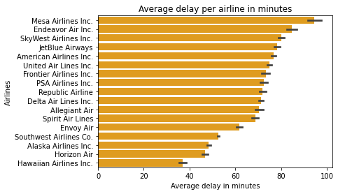

```python
#Create bar chart, the x axis will be the average total delay in minutes
sns.barplot(data=flight_copy, x='TOTAL_DELAY', y='CARRIER_DESCRIPTION', order=order, color='orange')
plt.ylabel('Airlines')
plt.xlabel('Average delay in minutes')
plt.title('Average delay per airline in minutes');
```

The airlines with the longest delays (on average) are Mesa Airlines, Endeavor Air, SkyWest, JetBlue, and American Airlines. The airlines with the best performances are Alaska Airlines, Horizon Air and Hawaiian Airlines.

Now that we have looked at the correlation between distance and delays let's look at distance and cancellation. Are longer flights more susceptible to cancellation than shorter flights?

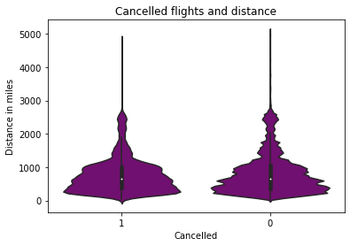

```python
#Create a violon plot of the cancelled vs distance variable
sns.violinplot(data=flight_copy, x='CANCELLED', y='DISTANCE', color='purple')
plt.ylabel('Distance in miles')
plt.xlabel('Cancelled')
plt.title('Cancelled flights and distance');
```

The two plots are very similar. Distance in miles does not correlate with whether a flight will be canceled.

### Talk about some of the relationships you observed in this part of the investigation. How did the feature(s) of interest vary with other features in the dataset?

Weather delays were an average an hour long, although they happened less frequently than other delays. It is also the main reason for cancellation for most airlines.

On average, the airlines with the most prolonged delays were Mesa Airlines, Endeavor Air, and Skywest. The airlines with the highest cancellation percentage were Republic Airlines, Endeavor Air, and American Airlines.

The three airlines that performed the best in both categories were Alaska Airlines, Hawaiian Airlines, and Horizon Air.

Flights leaving from and to New Jersey, Maine, New York, and Rhode Island are more likely to be canceled during the summer months. Flights departing from and going to Delaware were delayed by over an hour.

### Did you observe any interesting relationships between the other features (not the main feature(s) of interest)?

There is a slight negative correlation between distance and delays: short and medium flights were more susceptible to long delays than long-haul flights. It is interesting because this is unexpected; we would have guessed that longer flights would be more prone to delays.

However, we didn't observe any correlation between cancellation and distance. Longer flights are not more likely to be canceled than shorter flights.

Cancellation happened more often during June and August. Because our dataset consists of 2022 only, the sample is not large enough for us to draw any decisive conclusion concerning the months. We would have to compare those months to other future or past years to see if any pattern exists.

## Multivariate Exploration

Diving deeper into the delayed and canceled flights.

As seen previously, there is not an even number of flights each day, each hour, each month. Some days and parts of the day have a higher traffic than others. For comparison, we then have to work with percentages rather than numbers. What is the rate of cancellation for a Tuesday vs a Wednesday? Afternoon vs Evening?

Let's look first at the cancellation and delay rate throughout the day. Is a flight most likely to be canceled or delayed at night or in the afternoon?

First, we need to find the number of canceled flights per time period using Groupby.

```python
#Group by time of day and count the CANCELLATION_CODE column to get the number of cancelled flights
flight_copy.groupby('TIME_OF_DAY')['CANCELLATION_CODE'].count()
```

```
TIME_OF_DAY
Morning      15429
Afternoon    18003
Evening      16832
Night         1258
Name: CANCELLATION_CODE, dtype: int64
```

Divide the number of canceled flights by the total of flights for each period and multiply by 100 to get the percentage, rounded to two decimals. Save our results under a dataframe.

```python
#Get the percentage of flight rounded to 2 decimals
tod_cancelled = np.round((flight_copy.groupby('TIME_OF_DAY')['CANCELLATION_CODE'].count()\
                          / flight_copy['TIME_OF_DAY'].value_counts()) *100,2)
#Creat a dataframe using reset_index, rename columns for clarity
tod_cancelled = tod_cancelled.reset_index().rename(columns={0: "CANCELLED_PERC"})
tod_cancelled
```

|  | TIME_OF_DAY | CANCELLED_PERC |
| --- | --- | --- |
| 0 | Morning | 1.72 |
| 1 | Afternoon | 2.22 |
| 2 | Evening | 3.14 |
| 3 | Night | 1.81 |

We now have the cancellation percentage for each part of the day.

To find the percentage of delayed flights, we can repeat the same calculations as above using the ARR_DELAY_NEW column. Count the number of delayed flights per time period and divide by the total number of flights (canceled flights not included) per time period. Multiply by 100 to get the percentage, round to two decimals and create a dataframe.

```python
#Number of delayed flights per time period
tod_delay = flight_copy.groupby('TIME_OF_DAY')['ARR_DELAY_NEW'].count()
tod_delay
```

```
TIME_OF_DAY
Morning      250007
Afternoon    341495
Evening      250496
Night         13577
Name: ARR_DELAY_NEW, dtype: int64
```

```python
#Total number of flights per time period
#I chose to use arr_time with groupby, to make sure the cancelled flights are excluded in the count
tod_total = flight_copy.groupby('TIME_OF_DAY')['ARR_TIME'].count()
tod_total
```

```
TIME_OF_DAY
Morning      880461
Afternoon    793653
Evening      519444
Night         68091
Name: ARR_TIME, dtype: int64
```

```python
#Get the percentage and round it to 2 decimals
tod_perc = np.round(tod_delay / tod_total * 100, 2)
#Create a dataframe using reset_index and rename columns for clarity
tod_perc = tod_perc.reset_index().rename(columns={0: "DELAY_PERCENTAGE"})
tod_perc
```

|  | TIME_OF_DAY | DELAY_PERCENTAGE |
| --- | --- | --- |
| 0 | Morning | 28.40 |
| 1 | Afternoon | 43.03 |
| 2 | Evening | 48.22 |
| 3 | Night | 19.94 |

We now have the delay percentage for each part of the day.

```python
#Merge the two dataframe together creating one master dataframe
master_del_canc = pd.merge(tod_cancelled, tod_perc).rename(columns={'CANCELLED_PERC': 'CANCELLED', 'DELAY_PERCENTAGE': 'DELAYED'})
master_del_canc
```

|  | TIME_OF_DAY | CANCELLED | DELAYED |
| --- | --- | --- | --- |
| 0 | Morning | 1.72 | 28.40 |
| 1 | Afternoon | 2.22 | 43.03 |
| 2 | Evening | 3.14 | 48.22 |
| 3 | Night | 1.81 | 19.94 |

Pivot the resulting dataframe so each observation forms a row (time of day, whether it is delayed or cancelled and the percentage).

```python
#Pivot the dataframe using melt
melt_df = master_del_canc.melt(id_vars='TIME_OF_DAY',\
                               value_vars =['CANCELLED', 'DELAYED'], var_name='TYPE', value_name='PERCENTAGE')
melt_df
```

|  | TIME_OF_DAY | TYPE | PERCENTAGE |
| --- | --- | --- | --- |
| 0 | Morning | CANCELLED | 1.72 |
| 1 | Afternoon | CANCELLED | 2.22 |
| 2 | Evening | CANCELLED | 3.14 |
| 3 | Night | CANCELLED | 1.81 |
| 4 | Morning | DELAYED | 28.40 |
| 5 | Afternoon | DELAYED | 43.03 |
| 6 | Evening | DELAYED | 48.22 |
| 7 | Night | DELAYED | 19.94 |

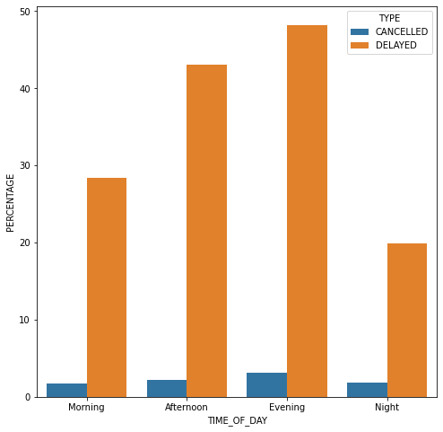

```python
#Create a bar plot with the percentage of cancelled and delayed flights for each time period
plt.figure(figsize=(8,8))
sns.barplot(data=melt_df, x='TIME_OF_DAY', y='PERCENTAGE', hue='TYPE');
```

As a reminder :

- Morning: Between 6am and noon
- Afternoon: Between noon and 6pm
- Evening: Between 6pm and midnight
- Night: Between midnight and 6am

However, this plot does not tell you when the longest delays tend to happen; it just shows that delays occur more frequently in the afternoons and evenings. Most travelers would rather be delayed by 30 minutes than 4 hours, which is not an information we can extract from this visualization.

To get this information, we need to focus on the arr_delay_bins instead, which tells us approximately how long the flight has been delayed. Plotting this with the time of day will give us the period that suffers the longest delays.

Since ARR_DELAY_BINS is an ordinal categorical variable in nature, we will use a pointplot.

We first need to find out the percentage for each delay bins and each time of day.

```python
#Get the total number of flights per time of day
tod_count= flight_copy['TIME_OF_DAY'].value_counts()
tod_count
```

```
Morning      895890
Afternoon    811656
Evening      536276
Night         69349
Name: TIME_OF_DAY, dtype: int64
```

```python
#Turn that into a dataframe using reset index. Rename columns for clarity
tod_count = flight_copy['TIME_OF_DAY'].value_counts().reset_index().rename(columns={'index':'TIME_OF_DAY', 'TIME_OF_DAY':'COUNT'})
tod_count
```

|  | TIME_OF_DAY | COUNT |
| --- | --- | --- |
| 0 | Morning | 895890 |
| 1 | Afternoon | 811656 |
| 2 | Evening | 536276 |
| 3 | Night | 69349 |

```python
#Get the number of flights per arr_delay_bins and time of day. Save that under a new dataframe
bins_count = flight_copy.groupby(['ARR_DELAY_BINS', 'TIME_OF_DAY']).size().reset_index().rename(columns={0:'COUNT'})
bins_count
```

|  | ARR_DELAY_BINS | TIME_OF_DAY | COUNT |
| --- | --- | --- | --- |
| 0 | Over an hour early | Morning | 26 |
| 1 | Over an hour early | Afternoon | 55 |
| 2 | Over an hour early | Evening | 43 |
| 3 | Over an hour early | Night | 3 |
| 4 | 30 to 60 minutes early | Morning | 17205 |
| 5 | 30 to 60 minutes early | Afternoon | 12437 |
| 6 | 30 to 60 minutes early | Evening | 9357 |
| 7 | 30 to 60 minutes early | Night | 898 |
| 8 | Less than 30 minutes early | Morning | 595654 |
| 9 | Less than 30 minutes early | Afternoon | 424646 |
| 10 | Less than 30 minutes early | Evening | 250747 |
| 11 | Less than 30 minutes early | Night | 52325 |
| 12 | On time | Morning | 17569 |
| 13 | On time | Afternoon | 15020 |
| 14 | On time | Evening | 8801 |
| 15 | On time | Night | 1288 |
| 16 | Less than an hour late | Morning | 212786 |
| 17 | Less than an hour late | Afternoon | 271439 |
| 18 | Less than an hour late | Evening | 190584 |
| 19 | Less than an hour late | Night | 11712 |
| 20 | 1 to 2 hours late | Morning | 21165 |
| 21 | 1 to 2 hours late | Afternoon | 43289 |
| 22 | 1 to 2 hours late | Evening | 39554 |
| 23 | 1 to 2 hours late | Night | 879 |
| 24 | 2 to 4 hours late | Morning | 11323 |
| 25 | 2 to 4 hours late | Afternoon | 20737 |
| 26 | 2 to 4 hours late | Evening | 16659 |
| 27 | 2 to 4 hours late | Night | 592 |
| 28 | 4 to 8 hours late | Morning | 3778 |
| 29 | 4 to 8 hours late | Afternoon | 4881 |
| 30 | 4 to 8 hours late | Evening | 1887 |
| 31 | 4 to 8 hours late | Night | 294 |
| 32 | 8 to 12 hours late | Morning | 620 |
| 33 | 8 to 12 hours late | Afternoon | 227 |
| 34 | 8 to 12 hours late | Evening | 605 |
| 35 | 8 to 12 hours late | Night | 68 |
| 36 | 12 to 24 hours late | Morning | 261 |
| 37 | 12 to 24 hours late | Afternoon | 898 |
| 38 | 12 to 24 hours late | Evening | 1192 |
| 39 | 12 to 24 hours late | Night | 31 |
| 40 | Over 24hours late | Morning | 73 |
| 41 | Over 24hours late | Afternoon | 24 |
| 42 | Over 24hours late | Evening | 15 |
| 43 | Over 24hours late | Night | 1 |

```python
#Merge the two dataframe together
tod_per = bins_count.merge(tod_count, on='TIME_OF_DAY')
tod_per
```

|  | ARR_DELAY_BINS | TIME_OF_DAY | COUNT_x | COUNT_y |
| --- | --- | --- | --- | --- |
| 0 | Over an hour early | Morning | 26 | 895890 |
| 1 | 30 to 60 minutes early | Morning | 17205 | 895890 |
| 2 | Less than 30 minutes early | Morning | 595654 | 895890 |
| 3 | On time | Morning | 17569 | 895890 |
| 4 | Less than an hour late | Morning | 212786 | 895890 |
| 5 | 1 to 2 hours late | Morning | 21165 | 895890 |
| 6 | 2 to 4 hours late | Morning | 11323 | 895890 |
| 7 | 4 to 8 hours late | Morning | 3778 | 895890 |
| 8 | 8 to 12 hours late | Morning | 620 | 895890 |
| 9 | 12 to 24 hours late | Morning | 261 | 895890 |
| 10 | Over 24hours late | Morning | 73 | 895890 |
| 11 | Over an hour early | Afternoon | 55 | 811656 |
| 12 | 30 to 60 minutes early | Afternoon | 12437 | 811656 |
| 13 | Less than 30 minutes early | Afternoon | 424646 | 811656 |
| 14 | On time | Afternoon | 15020 | 811656 |
| 15 | Less than an hour late | Afternoon | 271439 | 811656 |
| 16 | 1 to 2 hours late | Afternoon | 43289 | 811656 |
| 17 | 2 to 4 hours late | Afternoon | 20737 | 811656 |
| 18 | 4 to 8 hours late | Afternoon | 4881 | 811656 |
| 19 | 8 to 12 hours late | Afternoon | 227 | 811656 |
| 20 | 12 to 24 hours late | Afternoon | 898 | 811656 |
| 21 | Over 24hours late | Afternoon | 24 | 811656 |
| 22 | Over an hour early | Evening | 43 | 536276 |
| 23 | 30 to 60 minutes early | Evening | 9357 | 536276 |
| 24 | Less than 30 minutes early | Evening | 250747 | 536276 |
| 25 | On time | Evening | 8801 | 536276 |
| 26 | Less than an hour late | Evening | 190584 | 536276 |
| 27 | 1 to 2 hours late | Evening | 39554 | 536276 |
| 28 | 2 to 4 hours late | Evening | 16659 | 536276 |
| 29 | 4 to 8 hours late | Evening | 1887 | 536276 |
| 30 | 8 to 12 hours late | Evening | 605 | 536276 |
| 31 | 12 to 24 hours late | Evening | 1192 | 536276 |
| 32 | Over 24hours late | Evening | 15 | 536276 |
| 33 | Over an hour early | Night | 3 | 69349 |
| 34 | 30 to 60 minutes early | Night | 898 | 69349 |
| 35 | Less than 30 minutes early | Night | 52325 | 69349 |
| 36 | On time | Night | 1288 | 69349 |
| 37 | Less than an hour late | Night | 11712 | 69349 |
| 38 | 1 to 2 hours late | Night | 879 | 69349 |
| 39 | 2 to 4 hours late | Night | 592 | 69349 |
| 40 | 4 to 8 hours late | Night | 294 | 69349 |
| 41 | 8 to 12 hours late | Night | 68 | 69349 |
| 42 | 12 to 24 hours late | Night | 31 | 69349 |
| 43 | Over 24hours late | Night | 1 | 69349 |

```python
#Get the percentage, saving it under a new column
tod_per['PERCENTAGE'] = round((tod_per['COUNT_x'] / tod_per['COUNT_y']) *100, 3)
tod_per
```

|  | ARR_DELAY_BINS | TIME_OF_DAY | COUNT_x | COUNT_y | PERCENTAGE |
| --- | --- | --- | --- | --- | --- |
| 0 | Over an hour early | Morning | 26 | 895890 | 0.003 |
| 1 | 30 to 60 minutes early | Morning | 17205 | 895890 | 1.920 |
| 2 | Less than 30 minutes early | Morning | 595654 | 895890 | 66.487 |
| 3 | On time | Morning | 17569 | 895890 | 1.961 |
| 4 | Less than an hour late | Morning | 212786 | 895890 | 23.751 |
| 5 | 1 to 2 hours late | Morning | 21165 | 895890 | 2.362 |
| 6 | 2 to 4 hours late | Morning | 11323 | 895890 | 1.264 |
| 7 | 4 to 8 hours late | Morning | 3778 | 895890 | 0.422 |
| 8 | 8 to 12 hours late | Morning | 620 | 895890 | 0.069 |
| 9 | 12 to 24 hours late | Morning | 261 | 895890 | 0.029 |
| 10 | Over 24hours late | Morning | 73 | 895890 | 0.008 |
| 11 | Over an hour early | Afternoon | 55 | 811656 | 0.007 |
| 12 | 30 to 60 minutes early | Afternoon | 12437 | 811656 | 1.532 |
| 13 | Less than 30 minutes early | Afternoon | 424646 | 811656 | 52.318 |
| 14 | On time | Afternoon | 15020 | 811656 | 1.851 |
| 15 | Less than an hour late | Afternoon | 271439 | 811656 | 33.443 |
| 16 | 1 to 2 hours late | Afternoon | 43289 | 811656 | 5.333 |
| 17 | 2 to 4 hours late | Afternoon | 20737 | 811656 | 2.555 |
| 18 | 4 to 8 hours late | Afternoon | 4881 | 811656 | 0.601 |
| 19 | 8 to 12 hours late | Afternoon | 227 | 811656 | 0.028 |
| 20 | 12 to 24 hours late | Afternoon | 898 | 811656 | 0.111 |
| 21 | Over 24hours late | Afternoon | 24 | 811656 | 0.003 |
| 22 | Over an hour early | Evening | 43 | 536276 | 0.008 |
| 23 | 30 to 60 minutes early | Evening | 9357 | 536276 | 1.745 |
| 24 | Less than 30 minutes early | Evening | 250747 | 536276 | 46.757 |
| 25 | On time | Evening | 8801 | 536276 | 1.641 |
| 26 | Less than an hour late | Evening | 190584 | 536276 | 35.538 |
| 27 | 1 to 2 hours late | Evening | 39554 | 536276 | 7.376 |
| 28 | 2 to 4 hours late | Evening | 16659 | 536276 | 3.106 |
| 29 | 4 to 8 hours late | Evening | 1887 | 536276 | 0.352 |
| 30 | 8 to 12 hours late | Evening | 605 | 536276 | 0.113 |
| 31 | 12 to 24 hours late | Evening | 1192 | 536276 | 0.222 |
| 32 | Over 24hours late | Evening | 15 | 536276 | 0.003 |
| 33 | Over an hour early | Night | 3 | 69349 | 0.004 |
| 34 | 30 to 60 minutes early | Night | 898 | 69349 | 1.295 |
| 35 | Less than 30 minutes early | Night | 52325 | 69349 | 75.452 |
| 36 | On time | Night | 1288 | 69349 | 1.857 |
| 37 | Less than an hour late | Night | 11712 | 69349 | 16.888 |
| 38 | 1 to 2 hours late | Night | 879 | 69349 | 1.268 |
| 39 | 2 to 4 hours late | Night | 592 | 69349 | 0.854 |
| 40 | 4 to 8 hours late | Night | 294 | 69349 | 0.424 |
| 41 | 8 to 12 hours late | Night | 68 | 69349 | 0.098 |
| 42 | 12 to 24 hours late | Night | 31 | 69349 | 0.045 |
| 43 | Over 24hours late | Night | 1 | 69349 | 0.001 |

We now have the percentage of flights for each bins. For example, about 24% of morning flights are less than an hour late.

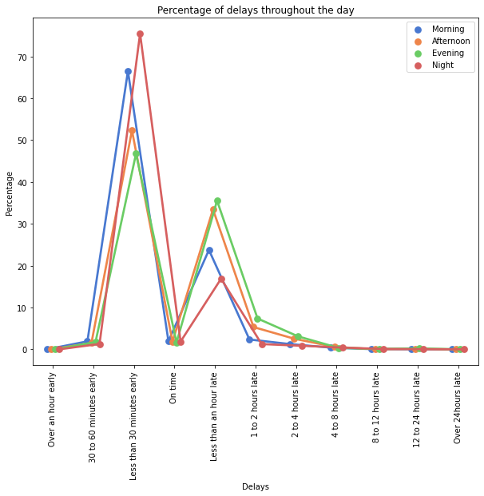

```python
#Create the pointplot
plt.figure(figsize=(10,8))
sns.pointplot(data=tod_per, x='ARR_DELAY_BINS', y='PERCENTAGE', hue='TIME_OF_DAY', dodge=0.3, palette='muted')
plt.xticks(rotation=90)
plt.ylabel('Percentage')
plt.xlabel('Delays')
plt.title('Percentage of delays throughout the day')
plt.legend(title='');
```

This plot is insightful. There is a peak at the "Less than 30 minutes early" mark for Morning, Afternoon, Evening, and Night, with 75% of Night flights and about 65% of Morning flights arriving between 0 and 29 minutes early.

After the "2 to 4 hours late," the plot becomes more challenging to read. Let's zoom in on this plot area until the "Over 24 hours late" mark.

```python
#Sort the dataframe by ARR_DELAY_BINS, save this under a new dataframe.
tod_per_sub = tod_per.sort_values(by='ARR_DELAY_BINS').reset_index(drop=True)
tod_per_sub
```

|  | ARR_DELAY_BINS | TIME_OF_DAY | COUNT_x | COUNT_y | PERCENTAGE |
| --- | --- | --- | --- | --- | --- |
| 0 | Over an hour early | Morning | 26 | 895890 | 0.003 |
| 1 | Over an hour early | Evening | 43 | 536276 | 0.008 |
| 2 | Over an hour early | Afternoon | 55 | 811656 | 0.007 |
| 3 | Over an hour early | Night | 3 | 69349 | 0.004 |
| 4 | 30 to 60 minutes early | Evening | 9357 | 536276 | 1.745 |
| 5 | 30 to 60 minutes early | Night | 898 | 69349 | 1.295 |
| 6 | 30 to 60 minutes early | Afternoon | 12437 | 811656 | 1.532 |
| 7 | 30 to 60 minutes early | Morning | 17205 | 895890 | 1.920 |
| 8 | Less than 30 minutes early | Evening | 250747 | 536276 | 46.757 |
| 9 | Less than 30 minutes early | Night | 52325 | 69349 | 75.452 |
| 10 | Less than 30 minutes early | Morning | 595654 | 895890 | 66.487 |
| 11 | Less than 30 minutes early | Afternoon | 424646 | 811656 | 52.318 |
| 12 | On time | Evening | 8801 | 536276 | 1.641 |
| 13 | On time | Afternoon | 15020 | 811656 | 1.851 |
| 14 | On time | Night | 1288 | 69349 | 1.857 |
| 15 | On time | Morning | 17569 | 895890 | 1.961 |
| 16 | Less than an hour late | Night | 11712 | 69349 | 16.888 |
| 17 | Less than an hour late | Evening | 190584 | 536276 | 35.538 |
| 18 | Less than an hour late | Morning | 212786 | 895890 | 23.751 |
| 19 | Less than an hour late | Afternoon | 271439 | 811656 | 33.443 |
| 20 | 1 to 2 hours late | Afternoon | 43289 | 811656 | 5.333 |
| 21 | 1 to 2 hours late | Evening | 39554 | 536276 | 7.376 |
| 22 | 1 to 2 hours late | Night | 879 | 69349 | 1.268 |
| 23 | 1 to 2 hours late | Morning | 21165 | 895890 | 2.362 |
| 24 | 2 to 4 hours late | Evening | 16659 | 536276 | 3.106 |
| 25 | 2 to 4 hours late | Night | 592 | 69349 | 0.854 |
| 26 | 2 to 4 hours late | Afternoon | 20737 | 811656 | 2.555 |
| 27 | 2 to 4 hours late | Morning | 11323 | 895890 | 1.264 |
| 28 | 4 to 8 hours late | Afternoon | 4881 | 811656 | 0.601 |
| 29 | 4 to 8 hours late | Evening | 1887 | 536276 | 0.352 |
| 30 | 4 to 8 hours late | Night | 294 | 69349 | 0.424 |
| 31 | 4 to 8 hours late | Morning | 3778 | 895890 | 0.422 |
| 32 | 8 to 12 hours late | Evening | 605 | 536276 | 0.113 |
| 33 | 8 to 12 hours late | Night | 68 | 69349 | 0.098 |
| 34 | 8 to 12 hours late | Morning | 620 | 895890 | 0.069 |
| 35 | 8 to 12 hours late | Afternoon | 227 | 811656 | 0.028 |
| 36 | 12 to 24 hours late | Afternoon | 898 | 811656 | 0.111 |
| 37 | 12 to 24 hours late | Evening | 1192 | 536276 | 0.222 |
| 38 | 12 to 24 hours late | Morning | 261 | 895890 | 0.029 |
| 39 | 12 to 24 hours late | Night | 31 | 69349 | 0.045 |
| 40 | Over 24hours late | Afternoon | 24 | 811656 | 0.003 |
| 41 | Over 24hours late | Morning | 73 | 895890 | 0.008 |
| 42 | Over 24hours late | Evening | 15 | 536276 | 0.003 |
| 43 | Over 24hours late | Night | 1 | 69349 | 0.001 |

```python
#Filter the dataframe to only keep the desired rows, using iloc
tod_per_sub = tod_per_sub.iloc[24:]
```

```python
#Print the dataframe
tod_per_sub
```

|  | ARR_DELAY_BINS | TIME_OF_DAY | COUNT_x | COUNT_y | PERCENTAGE |
| --- | --- | --- | --- | --- | --- |
| 24 | 2 to 4 hours late | Evening | 16659 | 536276 | 3.106 |
| 25 | 2 to 4 hours late | Night | 592 | 69349 | 0.854 |
| 26 | 2 to 4 hours late | Afternoon | 20737 | 811656 | 2.555 |
| 27 | 2 to 4 hours late | Morning | 11323 | 895890 | 1.264 |
| 28 | 4 to 8 hours late | Afternoon | 4881 | 811656 | 0.601 |
| 29 | 4 to 8 hours late | Evening | 1887 | 536276 | 0.352 |
| 30 | 4 to 8 hours late | Night | 294 | 69349 | 0.424 |
| 31 | 4 to 8 hours late | Morning | 3778 | 895890 | 0.422 |
| 32 | 8 to 12 hours late | Evening | 605 | 536276 | 0.113 |
| 33 | 8 to 12 hours late | Night | 68 | 69349 | 0.098 |
| 34 | 8 to 12 hours late | Morning | 620 | 895890 | 0.069 |
| 35 | 8 to 12 hours late | Afternoon | 227 | 811656 | 0.028 |
| 36 | 12 to 24 hours late | Afternoon | 898 | 811656 | 0.111 |
| 37 | 12 to 24 hours late | Evening | 1192 | 536276 | 0.222 |
| 38 | 12 to 24 hours late | Morning | 261 | 895890 | 0.029 |
| 39 | 12 to 24 hours late | Night | 31 | 69349 | 0.045 |
| 40 | Over 24hours late | Afternoon | 24 | 811656 | 0.003 |
| 41 | Over 24hours late | Morning | 73 | 895890 | 0.008 |
| 42 | Over 24hours late | Evening | 15 | 536276 | 0.003 |
| 43 | Over 24hours late | Night | 1 | 69349 | 0.001 |

```python
#Create a list of the x ticks order
x_order = ['2 to 4 hours late', '4 to 8 hours late', '8 to 12 hours late', '12 to 24 hours late', 'Over 24hours late']
x_order
```

```
['2 to 4 hours late',
 '4 to 8 hours late',
 '8 to 12 hours late',
 '12 to 24 hours late',
 'Over 24hours late']
```

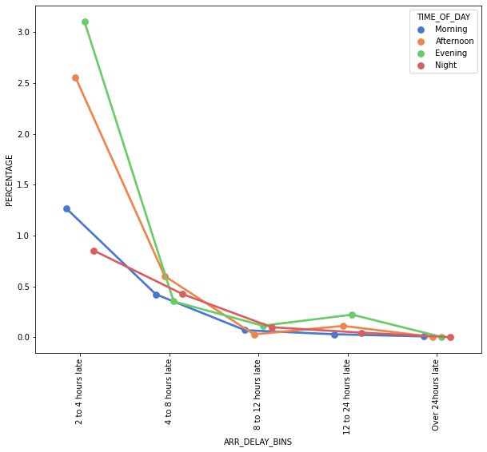

```python
#Plot the pointplot visualization using tod_per_sub
plt.figure(figsize=(10,8))
sns.pointplot(data=tod_per_sub, x='ARR_DELAY_BINS', y='PERCENTAGE', hue='TIME_OF_DAY', dodge=0.3, palette='muted',\
              order=x_order)
plt.xticks(rotation=90);
```

We are now able to make a couple of observations:

- The flights that have been delayed by 4 hours or less and by 12 to 24 hours late happened more frequently in the afternoon and evening.
- Less than 0.1% of flights are delayed by over 24 hours; however, it happens slightly more often in the Morning.

Regardless of when it leaves, the chance of your flight being late for more than 8 hours is slim; we are looking at less than 0.5% chance. However, Evening, compared to Afternoon, tends to have longer delays. So, on top of having more frequent delays, they tend to be longer in the evening, too.

Now, it would be interesting to know how the cancellations and delays spread out throughout the week. Is there a day of the week that is better avoided? To find out, we can repeat the steps we used to create the previous bar plot, using the days of the week instead of the time of the day.

```python
#Group by day of the week and count the CANCELLATION_CODE column to get the number of cancelled flights
count_week_cancel = flight_copy.groupby('DAY_OF_WEEK')['CANCELLATION_CODE'].count()
count_week_cancel
```

```
DAY_OF_WEEK
1     7252
2     5004
3     8300
4    10787
5     8480
6     4916
7     6783
Name: CANCELLATION_CODE, dtype: int64
```

```python
#Get the total number of flights per day of the week using value_counts().
#Use sort_index to get the index in the same order as above.
count_week_total = flight_copy['DAY_OF_WEEK'].value_counts().sort_index()
count_week_total
```

```
1    333899
2    315414
3    336010
4    354167
5    354374
6    292590
7    326717
Name: DAY_OF_WEEK, dtype: int64
```

```python
#Get the percentage of cancelled flights rounded to 2 decimals
week_cancelled = np.round((count_week_cancel / count_week_total) *100,2)
week_cancelled
```

```
DAY_OF_WEEK
1    2.17
2    1.59
3    2.47
4    3.05
5    2.39
6    1.68
7    2.08
dtype: float64
```

```python
#Create a dataframe using reset_index, rename columns for clarity
week_cancelled = week_cancelled.reset_index().rename(columns={0: "CANCELLED_PERC"})
week_cancelled
```

|  | DAY_OF_WEEK | CANCELLED_PERC |
| --- | --- | --- |
| 0 | 1 | 2.17 |
| 1 | 2 | 1.59 |
| 2 | 3 | 2.47 |
| 3 | 4 | 3.05 |
| 4 | 5 | 2.39 |
| 5 | 6 | 1.68 |
| 6 | 7 | 2.08 |

```python
#Get the number of delayed flights per week day
delay_per_day = flight_copy.groupby('DAY_OF_WEEK')['ARR_DELAY_NEW'].count()
delay_per_day
```

```
DAY_OF_WEEK
1    126377
2    104302
3    114163
4    134174
5    140392
6    105795
7    130372
Name: ARR_DELAY_NEW, dtype: int64
```

```python
#Get the total number of flights per week day
flight_per_day = flight_copy.groupby('DAY_OF_WEEK')['ARR_TIME'].count()
flight_per_day
```

```
DAY_OF_WEEK
1    326647
2    310410
3    327710
4    343380
5    345894
6    287674
7    319934
Name: ARR_TIME, dtype: int64
```

```python
#Get the percentage of delayed flights and round it to 2 decimals
week_delay = np.round(delay_per_day / flight_per_day * 100, 2)
week_delay
```

```
DAY_OF_WEEK
1    38.69
2    33.60
3    34.84
4    39.07
5    40.59
6    36.78
7    40.75
dtype: float64
```

```python
#Create a dataframe using reset_index and rename columns for clarity
week_delay = week_delay.reset_index().rename(columns={0: "DELAY_PERC"})
week_delay
```

|  | DAY_OF_WEEK | DELAY_PERC |
| --- | --- | --- |
| 0 | 1 | 38.69 |
| 1 | 2 | 33.60 |
| 2 | 3 | 34.84 |
| 3 | 4 | 39.07 |
| 4 | 5 | 40.59 |
| 5 | 6 | 36.78 |
| 6 | 7 | 40.75 |

```python
#Merge the two dataframe together creating one master dataframe
week_cancel_delay = pd.merge(week_cancelled, week_delay).rename(columns={'CANCELLED_PERC': 'CANCELLED', 'DELAY_PERC': 'DELAYED'})
week_cancel_delay
```

|  | DAY_OF_WEEK | CANCELLED | DELAYED |
| --- | --- | --- | --- |
| 0 | 1 | 2.17 | 38.69 |
| 1 | 2 | 1.59 | 33.60 |
| 2 | 3 | 2.47 | 34.84 |
| 3 | 4 | 3.05 | 39.07 |
| 4 | 5 | 2.39 | 40.59 |
| 5 | 6 | 1.68 | 36.78 |
| 6 | 7 | 2.08 | 40.75 |

```python
#Melt the dataframe to have one observation per row.
week_melt = week_cancel_delay.melt(id_vars='DAY_OF_WEEK',\
                               value_vars =['CANCELLED', 'DELAYED'], var_name='TYPE', value_name='PERCENTAGE')
week_melt
```

|  | DAY_OF_WEEK | TYPE | PERCENTAGE |
| --- | --- | --- | --- |
| 0 | 1 | CANCELLED | 2.17 |
| 1 | 2 | CANCELLED | 1.59 |
| 2 | 3 | CANCELLED | 2.47 |
| 3 | 4 | CANCELLED | 3.05 |
| 4 | 5 | CANCELLED | 2.39 |
| 5 | 6 | CANCELLED | 1.68 |
| 6 | 7 | CANCELLED | 2.08 |
| 7 | 1 | DELAYED | 38.69 |
| 8 | 2 | DELAYED | 33.60 |
| 9 | 3 | DELAYED | 34.84 |
| 10 | 4 | DELAYED | 39.07 |
| 11 | 5 | DELAYED | 40.59 |
| 12 | 6 | DELAYED | 36.78 |
| 13 | 7 | DELAYED | 40.75 |

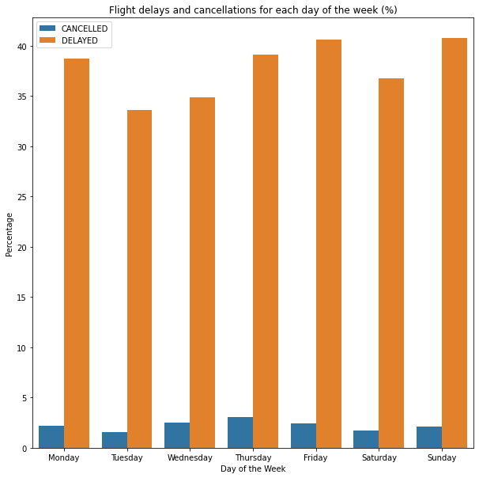

```python
#Create a bar plot with the percentage of cancelled and delayed flights for each day of the week.
plt.figure(figsize=(10,10))
ax = sns.barplot(data=week_melt, x='DAY_OF_WEEK', y='PERCENTAGE', hue='TYPE')
plt.title('Flight delays and cancellations for each day of the week (%)')
plt.ylabel('Percentage')
plt.xlabel('Day of the Week')
plt.legend(title='')
ax.set_xticklabels(['Monday', 'Tuesday', 'Wednesday', 'Thursday', 'Friday', 'Saturday', 'Sunday']);
```

The cancellation percentage is between 1.6% and 3%, and the delay percentage is between 34% and 41% throughout the week. Tuesday has the smallest cancellation and delay percentage compared to the rest of the week, but no other pattern is emerging. The correlation between delay/cancellation and the day of the week is slim.

Now that we have looked at the best and worst times to fly let's look into the airlines that are better avoided.

```python
#Group by airlines and get the number of cancelled flights
flight_groupby = flight_copy.groupby('CARRIER_DESCRIPTION')['CANCELLATION_CODE'].count().sort_index()
flight_groupby
```

```
CARRIER_DESCRIPTION
Alaska Airlines Inc.        582
Allegiant Air               978
American Airlines Inc.    11766
Delta Air Lines Inc.       5051
Endeavor Air Inc.          3747
Envoy Air                  1031
Frontier Airlines Inc.      971
Hawaiian Airlines Inc.       32
Horizon Air                 115
JetBlue Airways            2502
Mesa Airlines Inc.          889
PSA Airlines Inc.          2143
Republic Airline           5895
SkyWest Airlines Inc.      2039
Southwest Airlines Co.     8279
Spirit Air Lines           1185
United Air Lines Inc.      4317
Name: CANCELLATION_CODE, dtype: int64
```

```python
#Get the total of flights per airline
#Do not forget to sort index to get the airlines in the same order.
cancelled_airlines = flight_copy['CARRIER_DESCRIPTION'].value_counts().sort_index()
cancelled_airlines
```

```
Alaska Airlines Inc.       79385
Allegiant Air              40126
American Airlines Inc.    301087
Delta Air Lines Inc.      308424
Endeavor Air Inc.          77716
Envoy Air                  83712
Frontier Airlines Inc.     52337
Hawaiian Airlines Inc.     25592
Horizon Air                33052
JetBlue Airways            89382
Mesa Airlines Inc.         36867
PSA Airlines Inc.          72181
Republic Airline          106598
SkyWest Airlines Inc.     256641
Southwest Airlines Co.    458926
Spirit Air Lines           77486
United Air Lines Inc.     213659
Name: CARRIER_DESCRIPTION, dtype: int64
```

```python
#Create a new dataframe with the percentage of cancelled flights per airlines
carrier_cancelled = np.round((flight_groupby / cancelled_airlines) *100,2)
#Reset index and rename the columns for clarity
carrier_cancelled = carrier_cancelled.reset_index().rename(columns={0: "CANCELLED_PERC"})
carrier_cancelled
```

|  | CARRIER_DESCRIPTION | CANCELLED_PERC |
| --- | --- | --- |
| 0 | Alaska Airlines Inc. | 0.73 |
| 1 | Allegiant Air | 2.44 |
| 2 | American Airlines Inc. | 3.91 |
| 3 | Delta Air Lines Inc. | 1.64 |
| 4 | Endeavor Air Inc. | 4.82 |
| 5 | Envoy Air | 1.23 |
| 6 | Frontier Airlines Inc. | 1.86 |
| 7 | Hawaiian Airlines Inc. | 0.13 |
| 8 | Horizon Air | 0.35 |
| 9 | JetBlue Airways | 2.80 |
| 10 | Mesa Airlines Inc. | 2.41 |
| 11 | PSA Airlines Inc. | 2.97 |
| 12 | Republic Airline | 5.53 |
| 13 | SkyWest Airlines Inc. | 0.79 |
| 14 | Southwest Airlines Co. | 1.80 |
| 15 | Spirit Air Lines | 1.53 |
| 16 | United Air Lines Inc. | 2.02 |

We have the percentage of cancellations for each airline; now, let's get the percentage of delays by going through the same steps as above.

```python
#Get the number of delayed flights per airline
delay_per_carrier = flight_copy.groupby('CARRIER_DESCRIPTION')['ARR_DELAY_NEW'].count()
delay_per_carrier
```

```
CARRIER_DESCRIPTION
Alaska Airlines Inc.       30050
Allegiant Air              21497
American Airlines Inc.    124647
Delta Air Lines Inc.       90709
Endeavor Air Inc.          20803
Envoy Air                  27749
Frontier Airlines Inc.     22503
Hawaiian Airlines Inc.     13636
Horizon Air                11683
JetBlue Airways            40446
Mesa Airlines Inc.         12328
PSA Airlines Inc.          25490
Republic Airline           32999
SkyWest Airlines Inc.      76295
Southwest Airlines Co.    210300
Spirit Air Lines           26131
United Air Lines Inc.      68309
Name: ARR_DELAY_NEW, dtype: int64
```

```python
#Get the total number of flights per airline
flight_per_carrier = flight_copy.groupby('CARRIER_DESCRIPTION')['ARR_TIME'].count()
flight_per_carrier
```

```
CARRIER_DESCRIPTION
Alaska Airlines Inc.       78803
Allegiant Air              39148
American Airlines Inc.    289321
Delta Air Lines Inc.      303373
Endeavor Air Inc.          73969
Envoy Air                  82681
Frontier Airlines Inc.     51366
Hawaiian Airlines Inc.     25560
Horizon Air                32937
JetBlue Airways            86880
Mesa Airlines Inc.         35978
PSA Airlines Inc.          70038
Republic Airline          100703
SkyWest Airlines Inc.     254602
Southwest Airlines Co.    450647
Spirit Air Lines           76301
United Air Lines Inc.     209342
Name: ARR_TIME, dtype: int64
```

```python
#Get the percentage of delayed flights per airlines per time period, rounded to 2 decimals
carrier_delayed = np.round(delay_per_carrier / flight_per_carrier * 100, 2)
carrier_delayed
```

```
CARRIER_DESCRIPTION
Alaska Airlines Inc.      38.13
Allegiant Air             54.91
American Airlines Inc.    43.08
Delta Air Lines Inc.      29.90
Endeavor Air Inc.         28.12
Envoy Air                 33.56
Frontier Airlines Inc.    43.81
Hawaiian Airlines Inc.    53.35
Horizon Air               35.47
JetBlue Airways           46.55
Mesa Airlines Inc.        34.27
PSA Airlines Inc.         36.39
Republic Airline          32.77
SkyWest Airlines Inc.     29.97
Southwest Airlines Co.    46.67
Spirit Air Lines          34.25
United Air Lines Inc.     32.63
dtype: float64
```

```python
#Create a dataframe using reset_index and rename columns for clarity
carrier_delayed = carrier_delayed.reset_index().rename(columns={0: "DELAY_PERC"})
carrier_delayed
```

|  | CARRIER_DESCRIPTION | DELAY_PERC |
| --- | --- | --- |
| 0 | Alaska Airlines Inc. | 38.13 |
| 1 | Allegiant Air | 54.91 |
| 2 | American Airlines Inc. | 43.08 |
| 3 | Delta Air Lines Inc. | 29.90 |
| 4 | Endeavor Air Inc. | 28.12 |
| 5 | Envoy Air | 33.56 |
| 6 | Frontier Airlines Inc. | 43.81 |
| 7 | Hawaiian Airlines Inc. | 53.35 |
| 8 | Horizon Air | 35.47 |
| 9 | JetBlue Airways | 46.55 |
| 10 | Mesa Airlines Inc. | 34.27 |
| 11 | PSA Airlines Inc. | 36.39 |
| 12 | Republic Airline | 32.77 |
| 13 | SkyWest Airlines Inc. | 29.97 |
| 14 | Southwest Airlines Co. | 46.67 |
| 15 | Spirit Air Lines | 34.25 |
| 16 | United Air Lines Inc. | 32.63 |